# Primary_GCN_ukbec

Amy Hicks

15/12/2021

```r
# First initialise the datasets/packages to use
CoExp10UKBEC::initDb(mandatory = T)
# Open ensembl
ensembl = useMart("ensembl", dataset = "hsapiens_gene_ensembl")
source(file.path(here::here("scripts", "CoExp_functions.R")))
```

# 1. Gene lists of interest

## 1.1. NSL complex

Firstly, the nine genes encoding the NSL complex will be focused on [(Sheikh et al., 2019)](https://www.ncbi.nlm.nih.gov/pmc/articles/PMC6607013/). These genes encode proteins which make up an **acetyltransferase complex** linked to both nuclear and mitochondrial gene expression.

```r
# Load gene list
NSL_list <- read.delim(file.path(here::here("data", "Gene_lists", "NSL_list.txt")))
# Make gene list vectors
NSL_genes <- as.character(NSL_list$Gene_symbol)
NSL_ENSG <- as.character(NSL_list$Ensembl_ID)
```

The number of genes in this list: **9**.

## 1.2. PD mendelian

A broad list of highly penetrant genes linked unexclusively to familial forms of Parkinson's disease was obtained from PanelApp [Parkinson disease and complex Parkinsonism version 1.68](https://panelapp.genomicsengland.co.uk/panels/39/), a list collected and validated by a group of experts.

```r
# Load list
PD_mendelian_list <- read.delim(file.path(here::here("data", "Gene_lists", "PD_mendelian_list.txt")))
# Make gene list vectors
PD_mendelian_genes <- as.character(PD_mendelian_list$Gene_symbol)
PD_mendelian_ENSG <- as.character(PD_mendelian_list$Ensembl_ID)
```

The number of genes in this list: **43**.

## 1.3. PD sporadic

A list of less penetrant, more common genes linked to sporadic Parkinson's disease was obtained from the latest GWAS, described as *"Of the genes possibly associated with at least one QTL in public reference datasets and therefore testable via summary-based Mendelian randomisation, the expression or methylation of 64% was significantly associated with a possible causal change in Parkinson's disease risk."*

```r
# Load list
PD_GWAS_list <- read.delim(file.path(here::here("data", "Gene_lists", "PD_GWAS_list.txt")))
# Make gene list vectors
PD_GWAS_genes <- as.character(PD_GWAS_list$Gene_symbol)
PD_GWAS_ENSG <- as.character(PD_GWAS_list$Ensembl_ID)
```

The number of genes in this list: **150**.

# 2. Frontal cortex co-expression network

## 2.1. Network structure

The overall structure of the network was first examined.

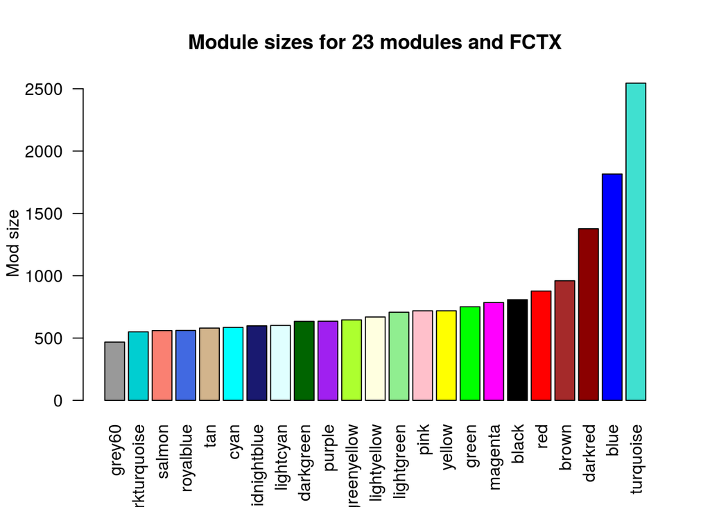

```r
# Display all modules in a specified tissue/network
CoExpNets::plotModSizes(tissue = "FCTX",
                        which.one = "10UKBEC")
```

```r
# Display network structure
Eigengenes <- getNetworkEigengenes(which.one = "10UKBEC",
                                   tissue = "FCTX")
cat("Frontal cortex network was obtained from", nrow(Eigengenes),
    "samples and has", ncol(Eigengenes), "modules\n")
```

```
## Frontal cortex network was obtained from 83 samples and has 23 modules
```

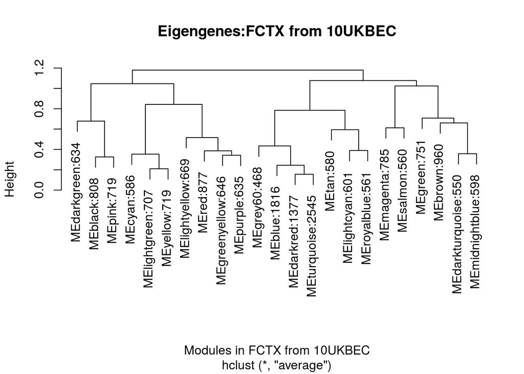

```r
plotEGClustering(which.one = "10UKBEC",
                 tissue = "FCTX")
```

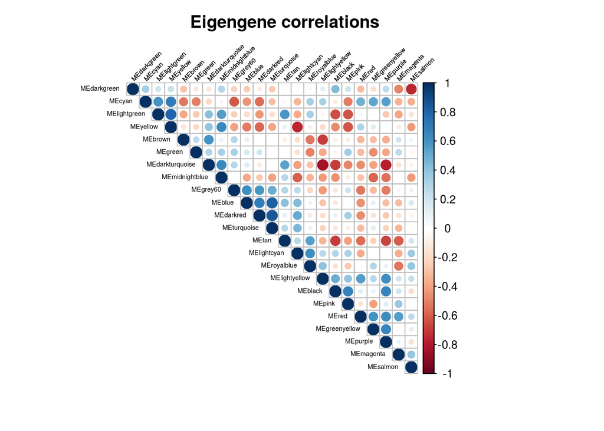

```r
# Display correlations between modules
corrplot(cor(Eigengenes), tl.srt = 45,
         tl.col = "black",
         type = "upper",
         tl.cex = 0.45,
         order = "hclust",
         title = paste0("Eigengene correlations"),
         mar = c(3, 2, 2.5, 4))
```

## 2.2. Gene set enrichment analysis

### NSL genes

First, the **NSL genes** were searched in the coexpression network.

```r
# Search for gene list in dataset
NSL_report_UK <- reportOnGenes(tissue = "FCTX",
                               genes = NSL_genes,
                               which.one = "10UKBEC")
# Select report
NSL_rep_UK <- NSL_report_UK$report
# Count the number of genes in the output
NSL_rep_UK_length <- nrow(NSL_rep_UK)
# Convert ENSGs in gene column to gene names
NSL_rep_UK$gene <- lapply(NSL_rep_UK$gene, fromEnsembl2GeneName)
```

The number of NSL genes is **9** and the number of genes in the search output was **4**, suggesting there were **5** genes missing from the search.

```r
# Show missing gene
dplyr::setdiff(NSL_genes, NSL_rep_UK$gene)
```

```
## [1] "KANSL1" "KANSL2" "KANSL3" "KAT8"   "WDR5"
```

```r
# Check source files if remaining gene is present
check_synonyms("FCTX",
               "10UKBEC",
               NSL_genes,
               NSL_rep_UK$gene)
```

| hgnc_symbol | external_synonym | ensembl_gene_id |
| --- | --- | --- |
| KANSL1 | KIAA1267 | ENSG00000275867 |
| KANSL1 | KIAA1267 | ENSG00000278458 |
| KANSL1 | KIAA1267 | ENSG00000120071 |
| KANSL2 | C12orf41 | ENSG00000139620 |
| KANSL3 | KIAA1310 | ENSG00000114982 |
| KAT8 | MYST1 | ENSG00000103510 |

**4** of the missing genes were present in this network under aliases so these were replaced in the input list. One of the genes, *KANSL1* seemed to appear in the network under multiple different ENSGs, so this needed to be checked.

```r
# Replace genes with alias names
NSL_UK_genes <- as.character(NSL_genes)
NSL_UK_genes[NSL_UK_genes=="KANSL1"] <- "KIAA1267"
NSL_UK_genes[NSL_UK_genes=="KAT8"] <- "MYST1"
NSL_UK_genes[NSL_UK_genes=="KANSL2"] <- "C12orf41"
NSL_UK_genes[NSL_UK_genes=="KANSL3"] <- "KIAA1310"
```

The search was then repeated with these changes.

```r
# Search for gene list in dataset
NSL_report2_UK <- reportOnGenes(tissue = "FCTX",
                                genes = NSL_UK_genes,
                                which.one = "10UKBEC")
# Select report
NSL_rep2_UK <- NSL_report2_UK$report
# Count the number of genes in the output
NSL_rep2_UK_length <- nrow(NSL_rep2_UK)
```

The remaining gene was not present in the source file under any aliases and searching in [Braineac](http://www.braineac.org/) itself suggests it is **not present** in this dataset.

```r
# Convert report into dataframe
NSL_rep2_UK <- data.frame(matrix(unlist(NSL_rep2_UK),
                                 nrow = NSL_rep2_UK_length,
                                 byrow = FALSE),
                          stringsAsFactors=FALSE)
names(NSL_rep2_UK)[2] <- "ENSG"
names(NSL_rep2_UK)[3] <- "MM"
names(NSL_rep2_UK)[4] <- "Module"
names(NSL_rep2_UK)[5] <- "Size"
names(NSL_rep2_UK)[6] <- "GO_report"
names(NSL_rep2_UK)[7] <- "PD_genes"
names(NSL_rep2_UK)[8] <- "Preservation"
names(NSL_rep2_UK)[9] <- "Cell_type"
names(NSL_rep2_UK)[10] <- "Fisher"
# Convert gene name column back to more common gene names
UK_genes <- unlist(lapply(NSL_rep2_UK$ENSG, fromEnsembl2GeneName))
UK_genes[UK_genes=="KIAA1267"] <- "KANSL1"
UK_genes[UK_genes=="MYST1"] <- "KAT8"
UK_genes[UK_genes=="C12orf41"] <- "KANSL2"
UK_genes[UK_genes=="KIAA1310"] <- "KANSL3"
# Convert ENSG column back to all ENSGs
UK_ENSGs <- unlist(NSL_rep2_UK$ENSG)
UK_ENSGs[UK_ENSGs=="KIAA1267"] <- "ENSG00000120071"
UK_ENSGs[UK_ENSGs=="MYST1"] <- "ENSG00000103510"
UK_ENSGs[UK_ENSGs=="C12orf41"] <- "ENSG00000139620"
UK_ENSGs[UK_ENSGs=="KIAA1310"] <- "ENSG00000114982"
# Remove first two columns
NSL_rep2_UK <- NSL_rep2_UK[, c(-1, -2)]
NSL_rep2_UK <- data.frame(UK_genes, UK_ENSGs, NSL_rep2_UK)
names(NSL_rep2_UK)[1] <- "Gene"
names(NSL_rep2_UK)[2] <- "ENSG"
# FDR correct
NSL_rep2_UK$FDR <- p.adjust(NSL_rep2_UK$Fisher, method = "fdr")
```

```r
# Print report
NSL_rep2_UK[,c(1,4,3,5,10,11,9)]
```

| Gene | Module | MM | Size | Fisher | FDR | Cell_type |
| --- | --- | --- | --- | --- | --- | --- |
| HCFC1 | black | 0.8568 | 808 | 0.0001921 | 0.0003842 | void |
| KANSL1 | black | 0.6885 | 808 | 0.0001921 | 0.0003842 | void |
| KAT8 | black | 0.4952 | 808 | 0.0001921 | 0.0003842 | void |
| MCRS1 | black | 0.5376 | 808 | 0.0001921 | 0.0003842 | void |
| KANSL2 | salmon | 0.5103 | 560 | 0.2114 | 0.2698286 | void |
| KANSL3 | darkgreen | 0.5061 | 634 | 0.2361 | 0.2698286 | void |
| OGT | royalblue | 0.6878 | 561 | 0.2117 | 0.2698286 | void |
| PHF20 | magenta | 0.7319 | 785 | 0.2846 | 0.2846000 | void |

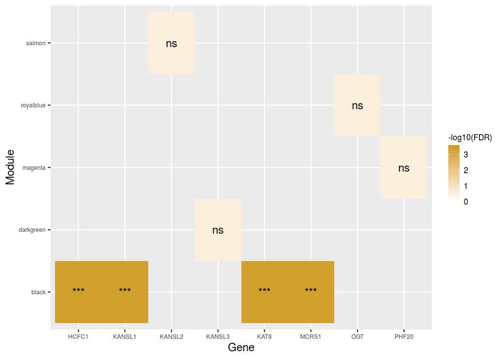

```r
# Store NSL enriched modules
NSL_UK_modules <- unique(NSL_rep2_UK$Module)
# Select columns needed for figure
NSL_fig_UK <- data.frame(NSL_rep2_UK$Module, NSL_rep2_UK$Gene, NSL_rep2_UK$FDR)
names(NSL_fig_UK)[names(NSL_fig_UK)=="NSL_rep2_UK.FDR"] <- "FDR"
names(NSL_fig_UK)[names(NSL_fig_UK)=="NSL_rep2_UK.Module"] <- "Module"
names(NSL_fig_UK)[names(NSL_fig_UK)=="NSL_rep2_UK.Gene"] <- "Gene"
# Prep for figure
NSL_fig_UK$FDR <- as.numeric(NSL_fig_UK$FDR)
NSL_fig_UK$Module <- as.character(NSL_fig_UK$Module)
NSL_fig_UK <- dplyr::arrange(NSL_fig_UK, Module)
NSL_fig_UK$`-log10(FDR)` <- -log10(NSL_fig_UK$FDR)
# Produce plot
ggplot(NSL_fig_UK, aes(Gene, Module)) +
  geom_tile(aes(fill = `-log10(FDR)`)) +
  geom_text(aes(label = signif.num(FDR))) +
  scale_fill_gradient(low = "white", high = "goldenrod3", limits = c(0,3.6)) +
  labs(y = "Module") +
  theme(
    axis.text = element_text(size = 6),
    legend.title = element_text(size = 8),
    legend.text = element_text(size = 8),
    legend.key.size = unit(4, "mm"))
```

The NSL genes appear in modules **black, salmon, darkgreen, royalblue, magenta** but were only significantly enriched in the **black** module. The eigengenes plot showed modules **black** and **darkgreen** to be relatively close together, as well as modules **royalblue**, **salmon** and **magenta**, suggesting the genes within these two groups of modules may have some level of coexpression.

### PD mendelian genes

Then the PD mendelian list was searched and the results filtered for the NSL enriched modules.

```r
# Search genes of interest in specified tissue/network
PD_mendelian_report_UK <- reportOnGenes(tissue = "FCTX",
                                        genes = PD_mendelian_genes,
                                        which.one = "10UKBEC")
# Select report
PD_mendelian_rep_UK <- PD_mendelian_report_UK$report
# Count number of genes in output
PD_mendelian_rep_UK_length <- nrow(PD_mendelian_rep_UK)
```

The number of genes is **43** and the number of genes in the search output was **40**, suggesting there were **3** genes missing from the search.

```r
# Show missing genes
dplyr::setdiff(PD_mendelian_genes, PD_mendelian_rep_UK$gene)
```

```
## [1] "MAPT"   "PRKN"   "TUBB4A"
```

```r
# Check if any synonyms of the genes are present in networks
check_synonyms("FCTX",
               "10UKBEC",
               PD_mendelian_genes,
               PD_mendelian_rep_UK$gene)
```

| hgnc_symbol | external_synonym | ensembl_gene_id |
| --- | --- | --- |
| PRKN | PARK2 | ENSG00000185345 |
| TUBB4A | TUBB4 | ENSG00000104833 |

**2** genes appeared in the network under alias names, so these were replaced in the search list.

```r
# Replace this in the list of genes
PD_mendelian_UK_genes <- as.character(PD_mendelian_genes)
PD_mendelian_UK_genes[PD_mendelian_UK_genes=="PRKN"] <- "PARK2"
PD_mendelian_UK_genes[PD_mendelian_UK_genes=="TUBB4A"] <- "TUBB4"
```

The search was then repeated with these changes.

```r
# Again search genes of interest in specified tissue/network
PD_mendelian_report2_UK <- reportOnGenes(tissue = "FCTX",
                                         genes = PD_mendelian_UK_genes,
                                         which.one = "10UKBEC")
# Select report
PD_mendelian_rep2_UK <- PD_mendelian_report2_UK$report
# Count number of genes in output
PD_mendelian_rep2_UK_length <- nrow(PD_mendelian_rep2_UK)
```

```r
dplyr::setdiff(PD_mendelian_UK_genes, PD_mendelian_rep2_UK$gene)
```

```
## [1] "MAPT"
```

The number of genes in the search output was **42**, showing there were **1** fewer genes than the original input list.

```r
# Convert report into dataframe
PD_mendelian_rep2_UK <- data.frame(matrix(unlist(PD_mendelian_rep2_UK),
                                          nrow = PD_mendelian_rep2_UK_length,
                                          byrow = FALSE),
                                   stringsAsFactors=FALSE)
names(PD_mendelian_rep2_UK)[1] <- "Gene"
names(PD_mendelian_rep2_UK)[2] <- "ENSG"
names(PD_mendelian_rep2_UK)[3] <- "MM"
names(PD_mendelian_rep2_UK)[4] <- "Module"
names(PD_mendelian_rep2_UK)[5] <- "Size"
names(PD_mendelian_rep2_UK)[6] <- "GO_report"
names(PD_mendelian_rep2_UK)[7] <- "PD_genes"
names(PD_mendelian_rep2_UK)[8] <- "Preservation"
names(PD_mendelian_rep2_UK)[9] <- "Cell_type"
names(PD_mendelian_rep2_UK)[10] <- "Fisher"
```

```r
# Filter for NSL modules
PD_mendelian_NSL_mod_UK <- PD_mendelian_rep2_UK %>%
  filter(Module %in% NSL_UK_modules)
# Print report without GO term and PD genes column
PD_mendelian_NSL_mod_UK[, c(1,4,3,5,10,9)]
```

| Gene | Module | MM | Size | Fisher | Cell_type |
| --- | --- | --- | --- | --- | --- |
| ATN1 | black | 0.8163 | 808 | 0.03092 | void |
| ATXN2 | black | 0.6882 | 808 | 0.03092 | void |
| GRN | black | 0.7037 | 808 | 0.03092 | void |
| OPA3 | black | 0.5422 | 808 | 0.03092 | void |
| TUBB4 | black | 0.8047 | 808 | 0.03092 | void |
| DCTN1 | darkgreen | 0.6243 | 634 | 0.1615 | void |
| HTT | darkgreen | 0.7136 | 634 | 0.1615 | void |
| TBP | darkgreen | 0.4784 | 634 | 0.1615 | void |
| SPG11 | salmon | 0.6375 | 560 | 0.7128 | void |

### PD sporadic genes

The PD sporadic list was also searched and the results filtered for the NSL enriched modules.

```r
# Search genes of interest in specified tissue/network
PD_GWAS_report_UK <- reportOnGenes(tissue = "FCTX",
                                   genes = PD_GWAS_genes,
                                   which.one = "10UKBEC")
# Select report
PD_GWAS_rep_UK <- PD_GWAS_report_UK$report
# Count the number of genes in the output
PD_GWAS_rep_UK_length <- nrow(PD_GWAS_rep_UK)
```

The number of PD GWAS genes is **150** and the number of genes in the search output was **122**, suggesting there were **28** genes missing from the search.

```r
# Show missing genes
dplyr::setdiff(PD_GWAS_genes, PD_GWAS_rep_UK$gene)
```

```
##  [1] "CCAR2"       "CSTA"        "EIF3C"       "FDFT1"       "HCG23"
##  [6] "HIST1H4J"    "HLA-DQA1"    "HLA-DQB1"    "HLA-DRB5"    "HLA-DRB6"
## [11] "KLHL7-DT"    "LINC00174"   "MALSU1"      "MAPT"        "MED13"
## [16] "PGF"         "PPIP5K2"     "PROX2"       "RAB29"       "RETREG3"
## [21] "SGF29"       "SLC26A1"     "TMEM163"     "TMEM248"     "VKORC1"
## [26] "ZKSCAN8"     "ZNF192P1"    "ZSCAN16-AS1"
```

```r
# Check if any synonyms of the genes are present in networks
check_synonyms("FCTX",
               "10UKBEC",
               PD_GWAS_genes,
               PD_GWAS_rep_UK$gene)
```

| hgnc_symbol | external_synonym | ensembl_gene_id |
| --- | --- | --- |
| CCAR2 | DBC1 | ENSG00000158941 |
| CCAR2 | KIAA1967 | ENSG00000158941 |
| LINC00174 | NCRNA00174 | ENSG00000179406 |
| MALSU1 | C7orf30 | ENSG00000156928 |
| PGF | PIGF | ENSG00000119630 |
| PPIP5K2 | HISPPD1 | ENSG00000145725 |
| RAB29 | RAB7L1 | ENSG00000117280 |
| RETREG3 | FAM134C | ENSG00000141699 |
| SGF29 | CCDC101 | ENSG00000176476 |
| TMEM248 | C7orf42 | ENSG00000106609 |

[output cut: 1 more lines]

**11** genes appeared in the network under alias names, so these were replaced in the search list.

```r
# Replace this in the list of genes
PD_GWAS_UK_genes <- as.character(PD_GWAS_genes)
PD_GWAS_UK_genes[PD_GWAS_UK_genes=="CCAR2"] <- "KIAA1967"
PD_GWAS_UK_genes[PD_GWAS_UK_genes=="LINC00174"] <- "NCRNA00174"
PD_GWAS_UK_genes[PD_GWAS_UK_genes=="MALSU1"] <- "C7orf30"
PD_GWAS_UK_genes[PD_GWAS_UK_genes=="PGF"] <- "PIGF"
PD_GWAS_UK_genes[PD_GWAS_UK_genes=="PPIP5K2"] <- "HISPPD1"
PD_GWAS_UK_genes[PD_GWAS_UK_genes=="RAB29"] <- "RAB7L1"
PD_GWAS_UK_genes[PD_GWAS_UK_genes=="RETREG3"] <- "FAM134C"
PD_GWAS_UK_genes[PD_GWAS_UK_genes=="SGF29"] <- "CCDC101"
PD_GWAS_UK_genes[PD_GWAS_UK_genes=="TMEM248"] <- "C7orf42"
PD_GWAS_UK_genes[PD_GWAS_UK_genes=="ZKSCAN8"] <- "ZNF192"
PD_GWAS_UK_genes[PD_GWAS_UK_genes=="ZNF192P1"] <- "ZNF389"
```

The search is was then repeated with these changes.

```r
# Again search genes of interest in specified tissue/network
PD_GWAS_report2_UK <- reportOnGenes(tissue = "FCTX",
                                    genes = PD_GWAS_UK_genes,
                                    which.one = "10UKBEC")
# Select report
PD_GWAS_rep2_UK <- PD_GWAS_report2_UK$report
# Count number of genes in output
PD_GWAS_rep2_UK_length <- nrow(PD_GWAS_rep2_UK)
```

```r
dplyr::setdiff(PD_GWAS_UK_genes, PD_GWAS_rep2_UK$gene)
```

```
##  [1] "CSTA"        "EIF3C"       "FDFT1"       "HCG23"       "HIST1H4J"
##  [6] "HLA-DQA1"    "HLA-DQB1"    "HLA-DRB5"    "HLA-DRB6"    "KLHL7-DT"
## [11] "MAPT"        "MED13"       "PROX2"       "SLC26A1"     "TMEM163"
## [16] "VKORC1"      "ZSCAN16-AS1"
```

```r
# Convert report into dataframe
PD_GWAS_rep2_UK <- data.frame(matrix(unlist(PD_GWAS_rep2_UK),
                                     nrow = PD_GWAS_rep2_UK_length,
                                     byrow = FALSE),
                              stringsAsFactors=FALSE)
names(PD_GWAS_rep2_UK)[1] <- "Gene"
names(PD_GWAS_rep2_UK)[2] <- "ENSG"
names(PD_GWAS_rep2_UK)[3] <- "MM"
names(PD_GWAS_rep2_UK)[4] <- "Module"
names(PD_GWAS_rep2_UK)[5] <- "Size"
names(PD_GWAS_rep2_UK)[6] <- "GO_report"
names(PD_GWAS_rep2_UK)[7] <- "PD_genes"
names(PD_GWAS_rep2_UK)[8] <- "Preservation"
names(PD_GWAS_rep2_UK)[9] <- "Cell_type"
names(PD_GWAS_rep2_UK)[10] <- "Fisher"
```

```r
# Filter for NSL modules
PD_GWAS_NSL_mod_UK <- PD_GWAS_rep2_UK %>%
  filter(Module %in% NSL_UK_modules)
# Print report without GO term and PD genes column
PD_GWAS_NSL_mod_UK[, c(1,4,3,5,10,9)]
```

| Gene | Module | MM | Size | Fisher | Cell_type |
| --- | --- | --- | --- | --- | --- |
| IGSF9B | royalblue | 0.4302 | 561 | 0.5551 | void |
| SATB1 | darkgreen | 0.2442 | 634 | 0.03422 | void |
| KIAA1967 | darkgreen | 0.6345 | 634 | 0.03422 | void |
| CCDC71 | darkgreen | 0.2413 | 634 | 0.03422 | void |
| DALRD3 | darkgreen | 0.501 | 634 | 0.03422 | void |
| DPM3 | darkgreen | 0.416 | 634 | 0.03422 | void |
| GAK | darkgreen | 0.6363 | 634 | 0.03422 | void |
| KCNIP3 | darkgreen | 0.5091 | 634 | 0.03422 | void |
| QRICH1 | darkgreen | 0.6782 | 634 | 0.03422 | void |
| TMEM175 | darkgreen | 0.5425 | 634 | 0.03422 | void |

[output cut: 19 more lines]

### Gene ontology terms

To examine the functional characteristics of these modules, the GO term enrichments annotated to these modules were extracted and simplified according to parent terms.

```r
# Obtain gprofiler2 network annotations from the UKBEC package
e2 = read.csv(file.path(here::here("data",
                                   "CoExp_source",
                                   "netFCTX.12.signed.it.20.rds_cor_pca.rds_gprofiler.csv")),
              stringsAsFactors = FALSE)
# Extract all GO term enrichments from source file for modules of interest
NSL_UK_GO = e2[e2$query.number %in% NSL_UK_modules & e2$domain %in% c("BP", "CC", "MF"),]
NSL_UK_GO_2 <- dplyr::select(NSL_UK_GO, query.number, term.id, term.name, domain, p.value)
# Rename columns
names(NSL_UK_GO_2)[names(NSL_UK_GO_2)=="query.number"] <- "gene_list"
names(NSL_UK_GO_2)[names(NSL_UK_GO_2)=="term.id"] <- "go_id"
names(NSL_UK_GO_2)[names(NSL_UK_GO_2)=="domain"] <- "go_type"
names(NSL_UK_GO_2)[names(NSL_UK_GO_2)=="term.name"] <- "go_term"
# FDR correct p values
NSL_UK_GO_2$p.value <- as.numeric(NSL_UK_GO_2$p.value)
NSL_UK_GO_2$FDR <- p.adjust(NSL_UK_GO_2$p.value, method="fdr")
```

```r
# GO reduce
NSL_UK_GO_red <- go_reduce(pathway_df = NSL_UK_GO_2, threshold = 0.7, scores = NULL)
```

The GO term enrichments attached to these modules were extracted and simplified according to parent terms, then plotted.

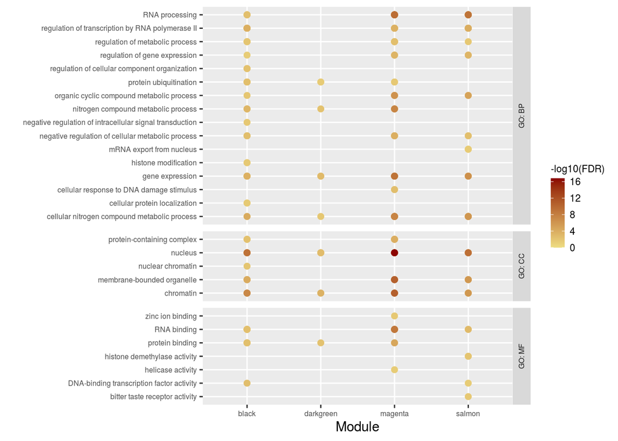

```r
# Format
NSL_UK_GO_red$go_type[NSL_UK_GO_red$go_type=="BP"] <- "GO: BP"
NSL_UK_GO_red$go_type[NSL_UK_GO_red$go_type=="MF"] <- "GO: MF"
NSL_UK_GO_red$go_type[NSL_UK_GO_red$go_type=="CC"] <- "GO: CC"
NSL_UK_GO_red <- NSL_UK_GO_red %>%
  tidyr::drop_na(parent_term) %>%
  dplyr::arrange(desc(FDR))
# Plot
ggplot2::ggplot(NSL_UK_GO_red, aes(x = gene_list, y = parent_term)) +
  geom_point(size = 2, aes(colour = -log10(`FDR`))) +
  scale_color_continuous(low = "lightgoldenrod", high = "red4", limits = c(0,16.8)) +
  facet_grid(go_type ~., scales = "free", space = "free") +
  labs(x = "Module", y = "") +
  theme(
    strip.text.y = element_text(angle = 90, size = 6),
    axis.text = element_text(size = 6),
    legend.title = element_text(size = 8),
    legend.text = element_text(size = 8),
    legend.key.size = unit(4, "mm")
    )
```

## 2.2. Summary

The **frequency** of **genes** within each gene **list** apppearing in each of the **5 NSL enriched modules** was calculated.

```r
# Collate module results into one table
UK1 <- PD_mendelian_NSL_mod_UK['Module']
UK1['Gene_list'] <- "PD_mendelian"
UK2 <- PD_GWAS_NSL_mod_UK['Module']
UK2['Gene_list'] <- "PD_GWAS"
UK_mods_list <- do.call(rbind, list(UK1, UK2))
# Display as frequency of each module within each list
UK_mod_freq <- with(UK_mods_list, table(Module, Gene_list))
UK_mod_freq <- as.data.frame.matrix(UK_mod_freq)
```

```r
knitr::kable(UK_mod_freq[c(5,1,4,2,3),])
```

|  | PD_GWAS | PD_mendelian |
| --- | --- | --- |
| salmon | 1 | 1 |
| black | 11 | 5 |
| royalblue | 4 | 0 |
| darkgreen | 9 | 3 |
| magenta | 4 | 0 |

The **significance** of the **enrichments** of each **gene list** within each of the **5 NSL enriched modules** was also calculated. P-values were **FDR-corrected** before summarising.

```r
# FDR correct p values
PD_mendelian_rep2_UK$FDR <- p.adjust(PD_mendelian_rep2_UK$Fisher, method = "fdr")
PD_GWAS_rep2_UK$FDR <- p.adjust(PD_GWAS_rep2_UK$Fisher, method = "fdr")
```

```r
# Collate module results into one table
UKs1 <- data.frame(PD_mendelian_rep2_UK$Module, PD_mendelian_rep2_UK$FDR)
names(UKs1)[names(UKs1)=="PD_mendelian_rep2_UK.FDR"] <- "FDR"
names(UKs1)[names(UKs1)=="PD_mendelian_rep2_UK.Module"] <- "Module"
UKs1$Gene_list <- "PD_mendelian"
UKs2 <- data.frame(PD_GWAS_rep2_UK$Module, PD_GWAS_rep2_UK$FDR)
names(UKs2)[names(UKs2)=="PD_GWAS_rep2_UK.FDR"] <- "FDR"
names(UKs2)[names(UKs2)=="PD_GWAS_rep2_UK.Module"] <- "Module"
UKs2$Gene_list <- "PD_GWAS"
UK_pvals_list <- dplyr::bind_rows(UKs1, UKs2)
# Display as true/false table
UK_TF <- UK_pvals_list %>%
  dplyr::distinct() %>%
  tidyr::spread(Gene_list, FDR)
UK_TF <- dplyr::filter(UK_TF, Module %in% NSL_UK_modules)
UK_TF <- tibble::column_to_rownames(UK_TF, var = "Module")
```

```r
knitr::kable(UK_TF[c(5,1,4,2,3),])
```

|  | PD_GWAS | PD_mendelian |
| --- | --- | --- |
| salmon | 0.9815000 | 0.8838000 |
| black | 0.1118410 | 0.1019288 |
| royalblue | 0.8109851 | NA |
| darkgreen | 0.1118410 | 0.2914154 |
| magenta | 0.9722574 | NA |

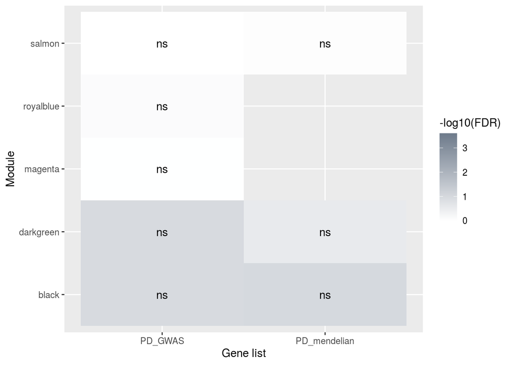

```r
# Filter out small mitopahgy list and modules without NSL genes
melt_summ_UK <- UK_pvals_list %>%
  dplyr::filter(Module %in% NSL_UK_modules) %>%
  dplyr::distinct()
# Prep for figure
melt_summ_UK$FDR <- as.numeric(melt_summ_UK$FDR)
melt_summ_UK$Module <- as.character(melt_summ_UK$Module)
melt_summ_UK$Gene_list <- as.character(melt_summ_UK$Gene_list)
melt_summ_UK <- dplyr::arrange(melt_summ_UK, Module)
melt_summ_UK$`-log10(FDR)` <- -log10(melt_summ_UK$FDR)
# Plot
ggplot(melt_summ_UK, aes(Gene_list, Module)) +
  geom_tile(aes(fill = `-log10(FDR)`)) +
  geom_text(aes(label = signif.num(FDR))) +
  scale_fill_gradient(low = "white", high = "lightsteelblue4", limits = c(0,3.6)) +
  labs(y = "Module", x = "Gene list")
```

# 3. Substantia nigra co-expression network

## 3.1. Network structure

The overall structure of the network was first examined.

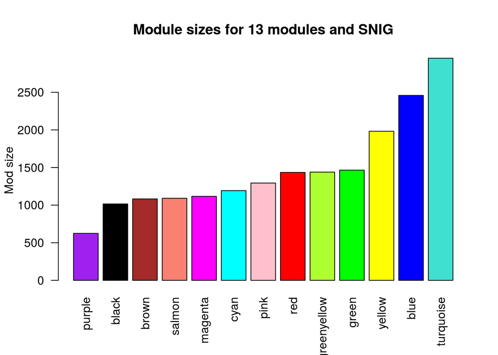

```r
# Display all modules in a specified tissue/network
CoExpNets::plotModSizes(tissue = "SNIG",
                        which.one = "10UKBEC")
```

```r
# Display network structure
Eigengenes <- getNetworkEigengenes(which.one = "10UKBEC",
                                   tissue = "SNIG")
cat("Substantia nigra network was obtained from", nrow(Eigengenes),
    "samples and has", ncol(Eigengenes), "modules\n")
```

```
## Substantia nigra network was obtained from 65 samples and has 13 modules
```

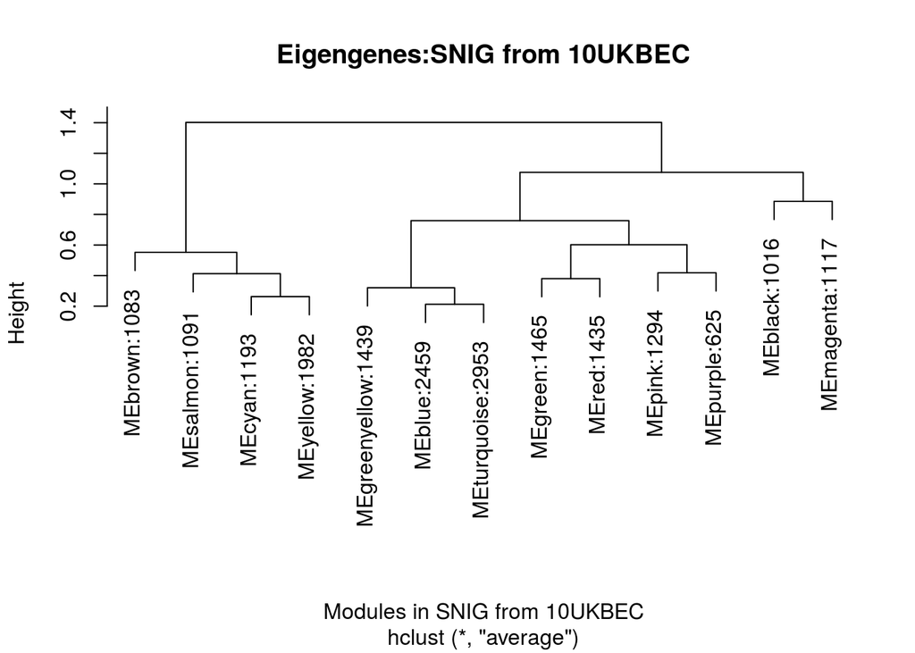

```r
plotEGClustering(which.one = "10UKBEC",
                 tissue = "SNIG")
```

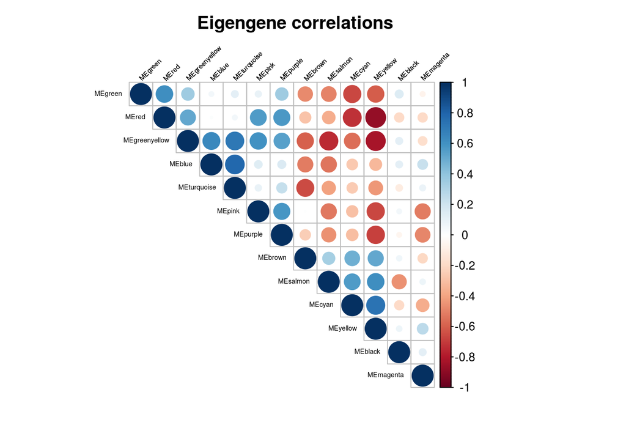

```r
# Display correlations between modules
corrplot(cor(Eigengenes), tl.srt = 45,
         tl.col = "black",
         type = "upper",
         tl.cex = 0.45,
         order = "hclust",
         title = paste0("Eigengene correlations"),
         mar = c(3, 2, 2.5, 4))
```

## 3.2. Gene set enrichment analysis

### NSL genes

First, the **NSL genes** were searched in the coexpression network.

```r
# Search for gene list in dataset
NSL_report2_UK <- reportOnGenes(tissue = "SNIG",
                                genes = NSL_UK_genes,
                                which.one = "10UKBEC")
# Select report
NSL_rep2_UK <- NSL_report2_UK$report
# Count the number of genes in the output
NSL_rep2_UK_length <- nrow(NSL_rep2_UK)
```

The remaining gene was not present in the source file under any aliases and searching in [Braineac](http://www.braineac.org/) itself suggests it is **not present** in this dataset.

```r
# Convert report into dataframe
NSL_rep2_UK <- data.frame(matrix(unlist(NSL_rep2_UK),
                                 nrow = NSL_rep2_UK_length,
                                 byrow = FALSE),
                          stringsAsFactors=FALSE)
names(NSL_rep2_UK)[2] <- "ENSG"
names(NSL_rep2_UK)[3] <- "MM"
names(NSL_rep2_UK)[4] <- "Module"
names(NSL_rep2_UK)[5] <- "Size"
names(NSL_rep2_UK)[6] <- "GO_report"
names(NSL_rep2_UK)[7] <- "PD_genes"
names(NSL_rep2_UK)[8] <- "Preservation"
names(NSL_rep2_UK)[9] <- "Cell_type"
names(NSL_rep2_UK)[10] <- "Fisher"
# Convert gene name column back to more common gene names
UK_genes <- unlist(lapply(NSL_rep2_UK$ENSG, fromEnsembl2GeneName))
UK_genes[UK_genes=="KIAA1267"] <- "KANSL1"
UK_genes[UK_genes=="MYST1"] <- "KAT8"
UK_genes[UK_genes=="C12orf41"] <- "KANSL2"
UK_genes[UK_genes=="KIAA1310"] <- "KANSL3"
# Convert ENSG column back to all ENSGs
UK_ENSGs <- unlist(NSL_rep2_UK$ENSG)
UK_ENSGs[UK_ENSGs=="KIAA1267"] <- "ENSG00000120071"
UK_ENSGs[UK_ENSGs=="MYST1"] <- "ENSG00000103510"
UK_ENSGs[UK_ENSGs=="C12orf41"] <- "ENSG00000139620"
UK_ENSGs[UK_ENSGs=="KIAA1310"] <- "ENSG00000114982"
# Remove first two columns
NSL_rep2_UK <- NSL_rep2_UK[, c(-1, -2)]
NSL_rep2_UK <- data.frame(UK_genes, UK_ENSGs, NSL_rep2_UK)
names(NSL_rep2_UK)[1] <- "Gene"
names(NSL_rep2_UK)[2] <- "ENSG"
# FDR correct
NSL_rep2_UK$FDR <- p.adjust(NSL_rep2_UK$Fisher, method = "fdr")
```

```r
# Print report
NSL_rep2_UK[,c(1,4,3,5,10,11,9)]
```

| Gene | Module | MM | Size | Fisher | FDR | Cell_type |
| --- | --- | --- | --- | --- | --- | --- |
| HCFC1 | black | 0.7692 | 1016 | 0.006817 | 0.01817867 | void |
| KAT8 | black | 0.5135 | 1016 | 0.006817 | 0.01817867 | void |
| MCRS1 | black | 0.5613 | 1016 | 0.006817 | 0.01817867 | void |
| KANSL1 | green | 0.3648 | 1465 | 0.01868 | 0.02490667 | Oligodendrocyte (p-value 3.177e-62). Cortex_Oligo_Neuroexpresso (p-value 2.648e-37). Hippocampus_Oligo_Neuroexpresso (p-value 3.47e-27). Cerebellum_Oligo_Neuroexpresso (p-value 1.616e-18). DARMANIS_OL… |
| KANSL2 | green | 0.3579 | 1465 | 0.01868 | 0.02490667 | Oligodendrocyte (p-value 3.177e-62). Cortex_Oligo_Neuroexpresso (p-value 2.648e-37). Hippocampus_Oligo_Neuroexpresso (p-value 3.47e-27). Cerebellum_Oligo_Neuroexpresso (p-value 1.616e-18). DARMANIS_OL… |
| OGT | green | 0.2867 | 1465 | 0.01868 | 0.02490667 | Oligodendrocyte (p-value 3.177e-62). Cortex_Oligo_Neuroexpresso (p-value 2.648e-37). Hippocampus_Oligo_Neuroexpresso (p-value 3.47e-27). Cerebellum_Oligo_Neuroexpresso (p-value 1.616e-18). DARMANIS_OL… |
| KANSL3 | greenyellow | 0.5716 | 1439 | 0.4647 | 0.46470000 | Cortex_Endothelial_Neuroexpresso (p-value 6.122e-24). Endothelial (p-value 1.785e-12). DARMANIS_ENDOTHELIAL (p-value 5.695e-07). |
| PHF20 | brown | 0.5479 | 1083 | 0.3723 | 0.42548571 | void |

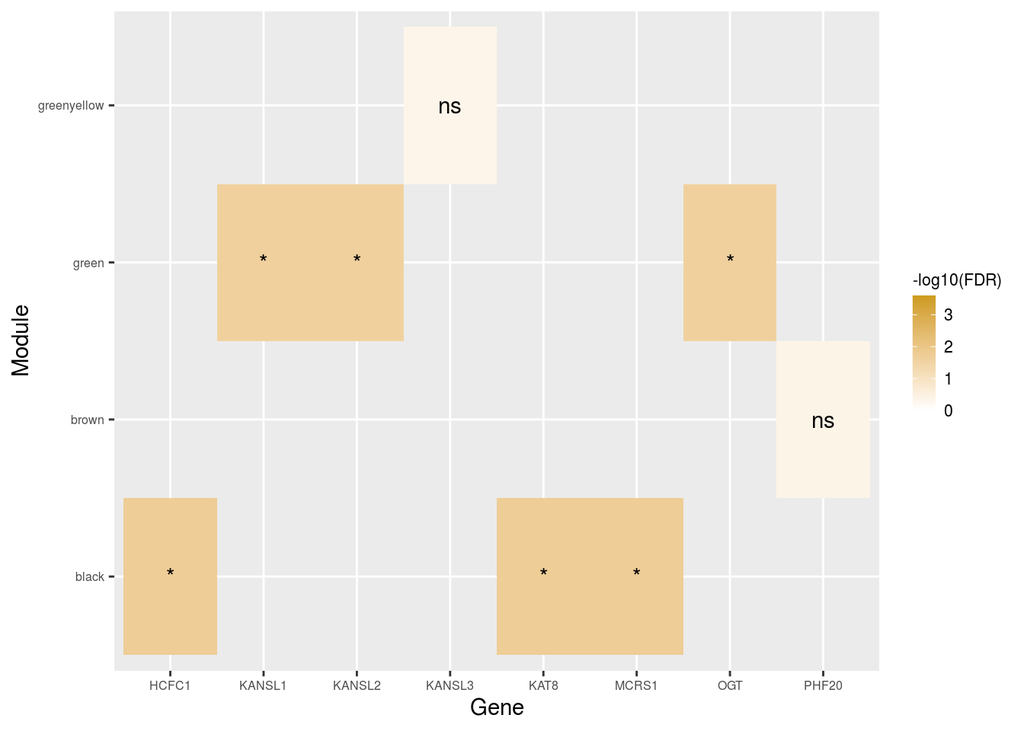

```r
# Store NSL enriched modules
NSL_UK_modules <- unique(NSL_rep2_UK$Module)
# Select columns needed for figure
NSL_fig_UK <- data.frame(NSL_rep2_UK$Module, NSL_rep2_UK$Gene, NSL_rep2_UK$FDR)
names(NSL_fig_UK)[names(NSL_fig_UK)=="NSL_rep2_UK.FDR"] <- "FDR"
names(NSL_fig_UK)[names(NSL_fig_UK)=="NSL_rep2_UK.Module"] <- "Module"
names(NSL_fig_UK)[names(NSL_fig_UK)=="NSL_rep2_UK.Gene"] <- "Gene"
# Prep for figure
NSL_fig_UK$FDR <- as.numeric(NSL_fig_UK$FDR)
NSL_fig_UK$Module <- as.character(NSL_fig_UK$Module)
NSL_fig_UK <- dplyr::arrange(NSL_fig_UK, Module)
NSL_fig_UK$`-log10(FDR)` <- -log10(NSL_fig_UK$FDR)
# Produce plot
ggplot(NSL_fig_UK, aes(Gene, Module)) +
  geom_tile(aes(fill = `-log10(FDR)`)) +
  geom_text(aes(label = signif.num(FDR))) +
  scale_fill_gradient(low = "white", high = "goldenrod3", limits = c(0,3.6)) +
  labs(y = "Module") +
  theme(
    axis.text = element_text(size = 6),
    legend.title = element_text(size = 8),
    legend.text = element_text(size = 8),
    legend.key.size = unit(4, "mm"))
```

The NSL genes appear in modules **black, green, greenyellow, brown** and were significantly enriched in the **black** and **green** modules.

### PD mendelian genes

Then the PD mendelian list was searched and the results filtered for the NSL enriched modules.

```r
# Search genes of interest in specified tissue/network
PD_mendelian_report_UK <- reportOnGenes(tissue = "SNIG",
                                        genes = PD_mendelian_genes,
                                        which.one = "10UKBEC")
# Select report
PD_mendelian_rep_UK <- PD_mendelian_report_UK$report
# Count number of genes in output
PD_mendelian_rep_UK_length <- nrow(PD_mendelian_rep_UK)
```

The number of genes is **43** and the number of genes in the search output was **40**, suggesting there were **3** genes missing from the search.

```r
# Show missing genes
dplyr::setdiff(PD_mendelian_genes, PD_mendelian_rep_UK$gene)
```

```
## [1] "MAPT"   "PRKN"   "TUBB4A"
```

```r
# Check if any synonyms of the genes are present in networks
check_synonyms("SNIG",
               "10UKBEC",
               PD_mendelian_genes,
               PD_mendelian_rep_UK$gene)
```

| hgnc_symbol | external_synonym | ensembl_gene_id |
| --- | --- | --- |
| PRKN | PARK2 | ENSG00000185345 |
| TUBB4A | TUBB4 | ENSG00000104833 |

**2** genes appeared in the network under alias names, so these were replaced in the search list.

```r
# Replace this in the list of genes
PD_mendelian_UK_genes <- as.character(PD_mendelian_genes)
PD_mendelian_UK_genes[PD_mendelian_UK_genes=="PRKN"] <- "PARK2"
PD_mendelian_UK_genes[PD_mendelian_UK_genes=="TUBB4A"] <- "TUBB4"
```

The search was then repeated with these changes.

```r
# Again search genes of interest in specified tissue/network
PD_mendelian_report2_UK <- reportOnGenes(tissue = "SNIG",
                                         genes = PD_mendelian_UK_genes,
                                         which.one = "10UKBEC")
# Select report
PD_mendelian_rep2_UK <- PD_mendelian_report2_UK$report
# Count number of genes in output
PD_mendelian_rep2_UK_length <- nrow(PD_mendelian_rep2_UK)
```

```r
dplyr::setdiff(PD_mendelian_UK_genes, PD_mendelian_rep2_UK$gene)
```

```
## [1] "MAPT"
```

The number of genes in the search output was **42**, showing there were **1** fewer genes than the original input list.

```r
# Convert report into dataframe
PD_mendelian_rep2_UK <- data.frame(matrix(unlist(PD_mendelian_rep2_UK),
                                          nrow = PD_mendelian_rep2_UK_length,
                                          byrow = FALSE),
                                   stringsAsFactors=FALSE)
names(PD_mendelian_rep2_UK)[1] <- "Gene"
names(PD_mendelian_rep2_UK)[2] <- "ENSG"
names(PD_mendelian_rep2_UK)[3] <- "MM"
names(PD_mendelian_rep2_UK)[4] <- "Module"
names(PD_mendelian_rep2_UK)[5] <- "Size"
names(PD_mendelian_rep2_UK)[6] <- "GO_report"
names(PD_mendelian_rep2_UK)[7] <- "PD_genes"
names(PD_mendelian_rep2_UK)[8] <- "Preservation"
names(PD_mendelian_rep2_UK)[9] <- "Cell_type"
names(PD_mendelian_rep2_UK)[10] <- "Fisher"
```

```r
# Filter for NSL modules
PD_mendelian_NSL_mod_UK <- PD_mendelian_rep2_UK %>%
  filter(Module %in% NSL_UK_modules)
# Print report without GO term and PD genes column
PD_mendelian_NSL_mod_UK[, c(1,4,3,5,10,9)]
```

| Gene | Module | MM | Size | Fisher | Cell_type |
| --- | --- | --- | --- | --- | --- |
| ATN1 | black | 0.6648 | 1016 | 0.1817 | void |
| ATXN2 | black | 0.3982 | 1016 | 0.1817 | void |
| GRN | black | 0.6666 | 1016 | 0.1817 | void |
| TUBB4 | black | 0.5967 | 1016 | 0.1817 | void |
| FBXO7 | green | 0.645 | 1465 | 0.8419 | Oligodendrocyte (p-value 3.177e-62). Cortex_Oligo_Neuroexpresso (p-value 2.648e-37). Hippocampus_Oligo_Neuroexpresso (p-value 3.47e-27). Cerebellum_Oligo_Neuroexpresso (p-value 1.616e-18). DARMANIS_OL… |
| PLA2G6 | green | 0.5038 | 1465 | 0.8419 | Oligodendrocyte (p-value 3.177e-62). Cortex_Oligo_Neuroexpresso (p-value 2.648e-37). Hippocampus_Oligo_Neuroexpresso (p-value 3.47e-27). Cerebellum_Oligo_Neuroexpresso (p-value 1.616e-18). DARMANIS_OL… |
| PANK2 | brown | 0.6678 | 1083 | 0.6952 | void |
| PARK7 | brown | 0.5182 | 1083 | 0.6952 | void |

### PD sporadic genes

The PD sporadic list was also searched and the results filtered for the NSL enriched modules.

```r
# Search genes of interest in specified tissue/network
PD_GWAS_report_UK <- reportOnGenes(tissue = "SNIG",
                                   genes = PD_GWAS_genes,
                                   which.one = "10UKBEC")
# Select report
PD_GWAS_rep_UK <- PD_GWAS_report_UK$report
# Count the number of genes in the output
PD_GWAS_rep_UK_length <- nrow(PD_GWAS_rep_UK)
```

The number of PD GWAS genes is **150** and the number of genes in the search output was **122**, suggesting there were **28** genes missing from the search.

```r
# Show missing genes
dplyr::setdiff(PD_GWAS_genes, PD_GWAS_rep_UK$gene)
```

```
##  [1] "CCAR2"       "CSTA"        "EIF3C"       "FDFT1"       "HCG23"
##  [6] "HIST1H4J"    "HLA-DQA1"    "HLA-DQB1"    "HLA-DRB5"    "HLA-DRB6"
## [11] "KLHL7-DT"    "LINC00174"   "MALSU1"      "MAPT"        "MED13"
## [16] "PGF"         "PPIP5K2"     "PROX2"       "RAB29"       "RETREG3"
## [21] "SGF29"       "SLC26A1"     "TMEM163"     "TMEM248"     "VKORC1"
## [26] "ZKSCAN8"     "ZNF192P1"    "ZSCAN16-AS1"
```

```r
# Check if any synonyms of the genes are present in networks
check_synonyms("SNIG",
               "10UKBEC",
               PD_GWAS_genes,
               PD_GWAS_rep_UK$gene)
```

| hgnc_symbol | external_synonym | ensembl_gene_id |
| --- | --- | --- |
| CCAR2 | DBC1 | ENSG00000158941 |
| CCAR2 | KIAA1967 | ENSG00000158941 |
| LINC00174 | NCRNA00174 | ENSG00000179406 |
| MALSU1 | C7orf30 | ENSG00000156928 |
| PGF | PIGF | ENSG00000119630 |
| PPIP5K2 | HISPPD1 | ENSG00000145725 |
| RAB29 | RAB7L1 | ENSG00000117280 |
| RETREG3 | FAM134C | ENSG00000141699 |
| SGF29 | CCDC101 | ENSG00000176476 |
| TMEM248 | C7orf42 | ENSG00000106609 |

[output cut: 1 more lines]

**11** genes appeared in the network under alias names, so these were replaced in the search list.

```r
# Replace this in the list of genes
PD_GWAS_UK_genes <- as.character(PD_GWAS_genes)
PD_GWAS_UK_genes[PD_GWAS_UK_genes=="CCAR2"] <- "KIAA1967"
PD_GWAS_UK_genes[PD_GWAS_UK_genes=="LINC00174"] <- "NCRNA00174"
PD_GWAS_UK_genes[PD_GWAS_UK_genes=="MALSU1"] <- "C7orf30"
PD_GWAS_UK_genes[PD_GWAS_UK_genes=="PGF"] <- "PIGF"
PD_GWAS_UK_genes[PD_GWAS_UK_genes=="PPIP5K2"] <- "HISPPD1"
PD_GWAS_UK_genes[PD_GWAS_UK_genes=="RAB29"] <- "RAB7L1"
PD_GWAS_UK_genes[PD_GWAS_UK_genes=="RETREG3"] <- "FAM134C"
PD_GWAS_UK_genes[PD_GWAS_UK_genes=="SGF29"] <- "CCDC101"
PD_GWAS_UK_genes[PD_GWAS_UK_genes=="TMEM248"] <- "C7orf42"
PD_GWAS_UK_genes[PD_GWAS_UK_genes=="ZKSCAN8"] <- "ZNF192"
PD_GWAS_UK_genes[PD_GWAS_UK_genes=="ZNF192P1"] <- "ZNF389"
```

The search is was then repeated with these changes.

```r
# Again search genes of interest in specified tissue/network
PD_GWAS_report2_UK <- reportOnGenes(tissue = "SNIG",
                                    genes = PD_GWAS_UK_genes,
                                    which.one = "10UKBEC")
# Select report
PD_GWAS_rep2_UK <- PD_GWAS_report2_UK$report
# Count number of genes in output
PD_GWAS_rep2_UK_length <- nrow(PD_GWAS_rep2_UK)
```

```r
dplyr::setdiff(PD_GWAS_UK_genes, PD_GWAS_rep2_UK$gene)
```

```
##  [1] "CSTA"        "EIF3C"       "FDFT1"       "HCG23"       "HIST1H4J"
##  [6] "HLA-DQA1"    "HLA-DQB1"    "HLA-DRB5"    "HLA-DRB6"    "KLHL7-DT"
## [11] "MAPT"        "MED13"       "PROX2"       "SLC26A1"     "TMEM163"
## [16] "VKORC1"      "ZSCAN16-AS1"
```

```r
# Convert report into dataframe
PD_GWAS_rep2_UK <- data.frame(matrix(unlist(PD_GWAS_rep2_UK),
                                     nrow = PD_GWAS_rep2_UK_length,
                                     byrow = FALSE),
                              stringsAsFactors=FALSE)
names(PD_GWAS_rep2_UK)[1] <- "Gene"
names(PD_GWAS_rep2_UK)[2] <- "ENSG"
names(PD_GWAS_rep2_UK)[3] <- "MM"
names(PD_GWAS_rep2_UK)[4] <- "Module"
names(PD_GWAS_rep2_UK)[5] <- "Size"
names(PD_GWAS_rep2_UK)[6] <- "GO_report"
names(PD_GWAS_rep2_UK)[7] <- "PD_genes"
names(PD_GWAS_rep2_UK)[8] <- "Preservation"
names(PD_GWAS_rep2_UK)[9] <- "Cell_type"
names(PD_GWAS_rep2_UK)[10] <- "Fisher"
```

```r
# Filter for NSL modules
PD_GWAS_NSL_mod_UK <- PD_GWAS_rep2_UK %>%
  filter(Module %in% NSL_UK_modules)
# Print report without GO term and PD genes column
PD_GWAS_NSL_mod_UK[, c(1,4,3,5,10,9)]
```

| Gene | Module | MM | Size | Fisher | Cell_type |
| --- | --- | --- | --- | --- | --- |
| AMPD3 | green | 0.2915 | 1465 | 0.3373 | Oligodendrocyte (p-value 3.177e-62). Cortex_Oligo_Neuroexpresso (p-value 2.648e-37). Hippocampus_Oligo_Neuroexpresso (p-value 3.47e-27). Cerebellum_Oligo_Neuroexpresso (p-value 1.616e-18). DARMANIS_OL… |
| ARIH2 | green | 0.5272 | 1465 | 0.3373 | Oligodendrocyte (p-value 3.177e-62). Cortex_Oligo_Neuroexpresso (p-value 2.648e-37). Hippocampus_Oligo_Neuroexpresso (p-value 3.47e-27). Cerebellum_Oligo_Neuroexpresso (p-value 1.616e-18). DARMANIS_OL… |
| DNAH17 | greenyellow | 0.3069 | 1439 | 0.4356 | Cortex_Endothelial_Neuroexpresso (p-value 6.122e-24). Endothelial (p-value 1.785e-12). DARMANIS_ENDOTHELIAL (p-value 5.695e-07). |
| ELOVL7 | green | 0.3698 | 1465 | 0.3373 | Oligodendrocyte (p-value 3.177e-62). Cortex_Oligo_Neuroexpresso (p-value 2.648e-37). Hippocampus_Oligo_Neuroexpresso (p-value 3.47e-27). Cerebellum_Oligo_Neuroexpresso (p-value 1.616e-18). DARMANIS_OL… |
| GALC | green | 0.3966 | 1465 | 0.3373 | Oligodendrocyte (p-value 3.177e-62). Cortex_Oligo_Neuroexpresso (p-value 2.648e-37). Hippocampus_Oligo_Neuroexpresso (p-value 3.47e-27). Cerebellum_Oligo_Neuroexpresso (p-value 1.616e-18). DARMANIS_OL… |
| HIP1R | green | 0.6984 | 1465 | 0.3373 | Oligodendrocyte (p-value 3.177e-62). Cortex_Oligo_Neuroexpresso (p-value 2.648e-37). Hippocampus_Oligo_Neuroexpresso (p-value 3.47e-27). Cerebellum_Oligo_Neuroexpresso (p-value 1.616e-18). DARMANIS_OL… |
| HSD3B7 | green | 0.2808 | 1465 | 0.3373 | Oligodendrocyte (p-value 3.177e-62). Cortex_Oligo_Neuroexpresso (p-value 2.648e-37). Hippocampus_Oligo_Neuroexpresso (p-value 3.47e-27). Cerebellum_Oligo_Neuroexpresso (p-value 1.616e-18). DARMANIS_OL… |
| NCRNA00174 | green | 0.5106 | 1465 | 0.3373 | Oligodendrocyte (p-value 3.177e-62). Cortex_Oligo_Neuroexpresso (p-value 2.648e-37). Hippocampus_Oligo_Neuroexpresso (p-value 3.47e-27). Cerebellum_Oligo_Neuroexpresso (p-value 1.616e-18). DARMANIS_OL… |
| MAL | green | 0.7581 | 1465 | 0.3373 | Oligodendrocyte (p-value 3.177e-62). Cortex_Oligo_Neuroexpresso (p-value 2.648e-37). Hippocampus_Oligo_Neuroexpresso (p-value 3.47e-27). Cerebellum_Oligo_Neuroexpresso (p-value 1.616e-18). DARMANIS_OL… |
| SCARB2 | green | 0.4955 | 1465 | 0.3373 | Oligodendrocyte (p-value 3.177e-62). Cortex_Oligo_Neuroexpresso (p-value 2.648e-37). Hippocampus_Oligo_Neuroexpresso (p-value 3.47e-27). Cerebellum_Oligo_Neuroexpresso (p-value 1.616e-18). DARMANIS_OL… |

[output cut: 31 more lines]

### Gene ontology terms

To examine the functional characteristics of these modules, the GO term enrichments annotated to these modules were extracted and simplified according to parent terms.

```r
# Obtain gprofiler2 network annotations from the UKBEC package
e2 = read.csv(file.path(here::here("data",
                                   "CoExp_source",
                                   "netSNIG.12.signed.it.20.rds_cor_pca.rds_gprofiler.csv")),
              stringsAsFactors = FALSE)
# Extract all GO term enrichments from source file for modules of interest
NSL_UK_GO = e2[e2$query.number %in% NSL_UK_modules & e2$domain %in% c("BP", "CC", "MF"),]
NSL_UK_GO_2 <- dplyr::select(NSL_UK_GO, query.number, term.id, term.name, domain, p.value)
# Rename columns
names(NSL_UK_GO_2)[names(NSL_UK_GO_2)=="query.number"] <- "gene_list"
names(NSL_UK_GO_2)[names(NSL_UK_GO_2)=="term.id"] <- "go_id"
names(NSL_UK_GO_2)[names(NSL_UK_GO_2)=="domain"] <- "go_type"
names(NSL_UK_GO_2)[names(NSL_UK_GO_2)=="term.name"] <- "go_term"
# FDR correct p values
NSL_UK_GO_2$p.value <- as.numeric(NSL_UK_GO_2$p.value)
NSL_UK_GO_2$FDR <- p.adjust(NSL_UK_GO_2$p.value, method="fdr")
```

```r
# GO reduce
NSL_UK_GO_red <- go_reduce(pathway_df = NSL_UK_GO_2,
                           threshold = 0.7,
                           scores = NULL)
```

The GO term enrichments attached to these modules were extracted and simplified according to parent terms, then plotted.

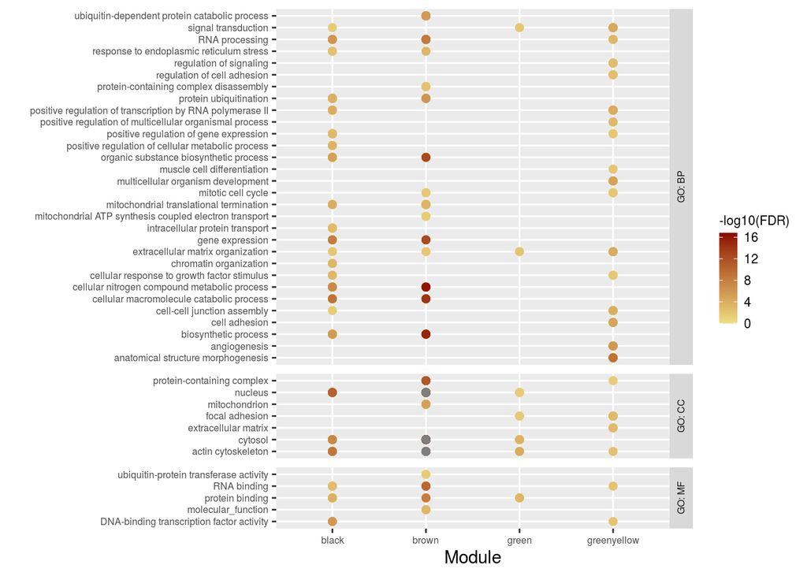

```r
# Format
NSL_UK_GO_red$go_type[NSL_UK_GO_red$go_type=="BP"] <- "GO: BP"
NSL_UK_GO_red$go_type[NSL_UK_GO_red$go_type=="MF"] <- "GO: MF"
NSL_UK_GO_red$go_type[NSL_UK_GO_red$go_type=="CC"] <- "GO: CC"
NSL_UK_GO_red <- NSL_UK_GO_red %>%
  tidyr::drop_na(parent_term) %>%
  dplyr::arrange(desc(FDR))
# Plot
ggplot2::ggplot(NSL_UK_GO_red, aes(x = gene_list, y = parent_term)) +
  geom_point(size = 2, aes(colour = -log10(`FDR`))) +
  scale_color_continuous(low = "lightgoldenrod", high = "red4", limits = c(0,16.8)) +
  facet_grid(go_type ~., scales = "free", space = "free") +
  labs(x = "Module", y = "") +
  theme(
    strip.text.y = element_text(angle = 90, size = 6),
    axis.text = element_text(size = 6),
    legend.title = element_text(size = 8),
    legend.text = element_text(size = 8),
    legend.key.size = unit(4, "mm")
    )
```

## 3.2. Summary

The **frequency** of **genes** within each gene **list** apppearing in each of the **4 NSL enriched modules** was calculated.

```r
# Collate module results into one table
UK1 <- PD_mendelian_NSL_mod_UK['Module']
UK1['Gene_list'] <- "PD_mendelian"
UK2 <- PD_GWAS_NSL_mod_UK['Module']
UK2['Gene_list'] <- "PD_GWAS"
UK_mods_list <- do.call(rbind, list(UK1, UK2))
# Display as frequency of each module within each list
UK_mod_freq <- with(UK_mods_list, table(Module, Gene_list))
UK_mod_freq <- as.data.frame.matrix(UK_mod_freq)
```

```r
knitr::kable(UK_mod_freq)
```

|  | PD_GWAS | PD_mendelian |
| --- | --- | --- |
| black | 15 | 4 |
| brown | 3 | 2 |
| green | 12 | 2 |
| greenyellow | 11 | 0 |

The **significance** of the **enrichments** of each **gene list** within each of the **4 NSL enriched modules** was also calculated. P-values were **FDR-corrected** before summarising.

```r
# FDR correct p values
PD_mendelian_rep2_UK$FDR <- p.adjust(PD_mendelian_rep2_UK$Fisher, method = "fdr")
PD_GWAS_rep2_UK$FDR <- p.adjust(PD_GWAS_rep2_UK$Fisher, method = "fdr")
```

```r
# Collate module results into one table
UKs1 <- data.frame(PD_mendelian_rep2_UK$Module, PD_mendelian_rep2_UK$FDR)
names(UKs1)[names(UKs1)=="PD_mendelian_rep2_UK.FDR"] <- "FDR"
names(UKs1)[names(UKs1)=="PD_mendelian_rep2_UK.Module"] <- "Module"
UKs1$Gene_list <- "PD_mendelian"
UKs2 <- data.frame(PD_GWAS_rep2_UK$Module, PD_GWAS_rep2_UK$FDR)
names(UKs2)[names(UKs2)=="PD_GWAS_rep2_UK.FDR"] <- "FDR"
names(UKs2)[names(UKs2)=="PD_GWAS_rep2_UK.Module"] <- "Module"
UKs2$Gene_list <- "PD_GWAS"
UK_pvals_list <- dplyr::bind_rows(UKs1, UKs2)
# Display as true/false table
UK_TF <- UK_pvals_list %>%
  dplyr::distinct() %>%
  tidyr::spread(Gene_list, FDR)
UK_TF <- dplyr::filter(UK_TF, Module %in% NSL_UK_modules)
UK_TF <- tibble::column_to_rownames(UK_TF, var = "Module")
```

```r
knitr::kable(UK_TF)
```

|  | PD_GWAS | PD_mendelian |
| --- | --- | --- |
| black | 0.0481500 | 0.2631517 |
| brown | 0.9911000 | 0.8342400 |
| green | 0.6153446 | 0.9556703 |
| greenyellow | 0.6918353 | NA |

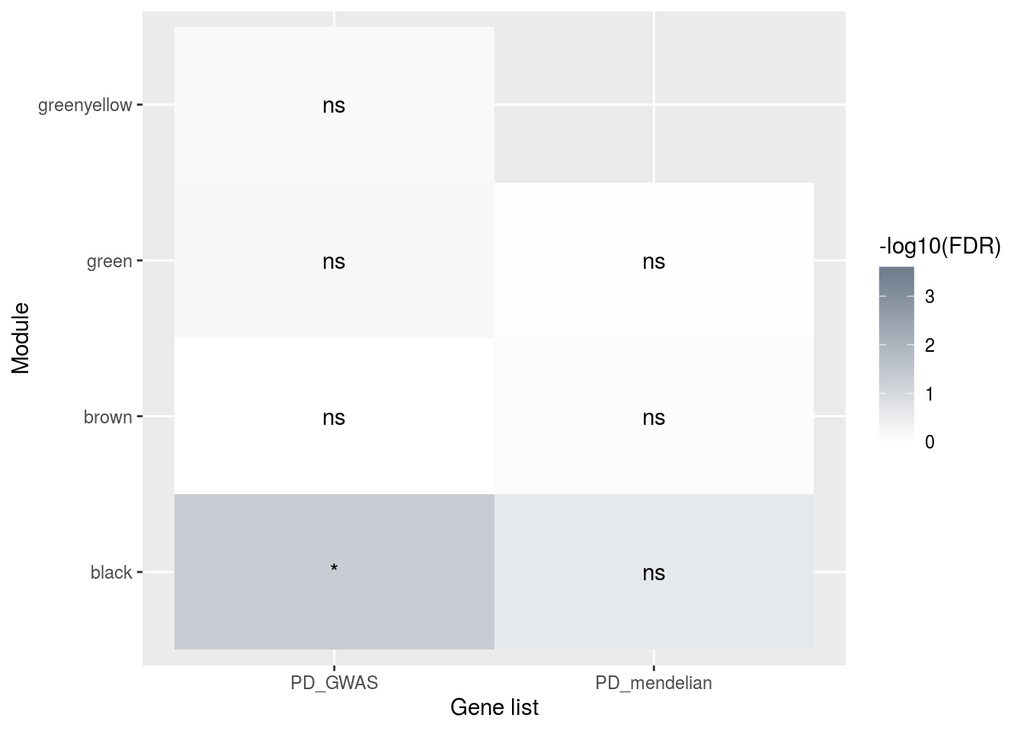

```r
# Filter out small mitopahgy list and modules without NSL genes
melt_summ_UK <- UK_pvals_list %>%
  dplyr::filter(Module %in% NSL_UK_modules) %>%
  dplyr::distinct()
# Prep for figure
melt_summ_UK$FDR <- as.numeric(melt_summ_UK$FDR)
melt_summ_UK$Module <- as.character(melt_summ_UK$Module)
melt_summ_UK$Gene_list <- as.character(melt_summ_UK$Gene_list)
melt_summ_UK <- dplyr::arrange(melt_summ_UK, Module)
melt_summ_UK$`-log10(FDR)` <- -log10(melt_summ_UK$FDR)
# Plot
ggplot(melt_summ_UK, aes(Gene_list, Module)) +
  geom_tile(aes(fill = `-log10(FDR)`)) +
  geom_text(aes(label = signif.num(FDR))) +
  scale_fill_gradient(low = "white", high = "lightsteelblue4", limits = c(0,3.6)) +
  labs(y = "Module", x = "Gene list")
```

# 4. Putamen co-expression network

## 4.1. Network structure

The overall structure of the network was first examined.

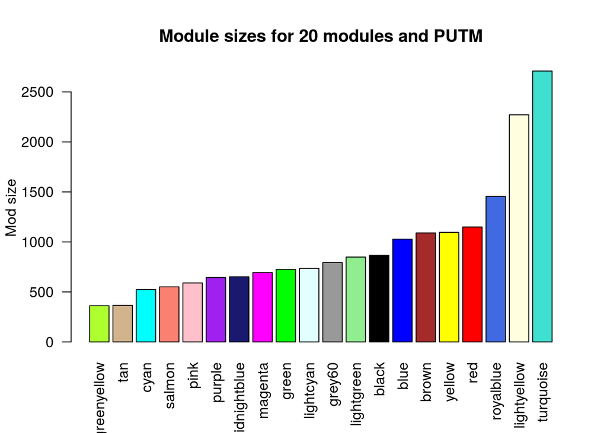

```r
# Display all modules in a specified tissue/network
CoExpNets::plotModSizes(tissue = "PUTM",
                        which.one = "10UKBEC")
```

```r
# Display network structure
Eigengenes <- getNetworkEigengenes(which.one = "10UKBEC", tissue = "PUTM")
cat("Putamen network was obtained from", nrow(Eigengenes),
    "samples and has", ncol(Eigengenes), "modules\n")
```

```
## Putamen network was obtained from 77 samples and has 20 modules
```

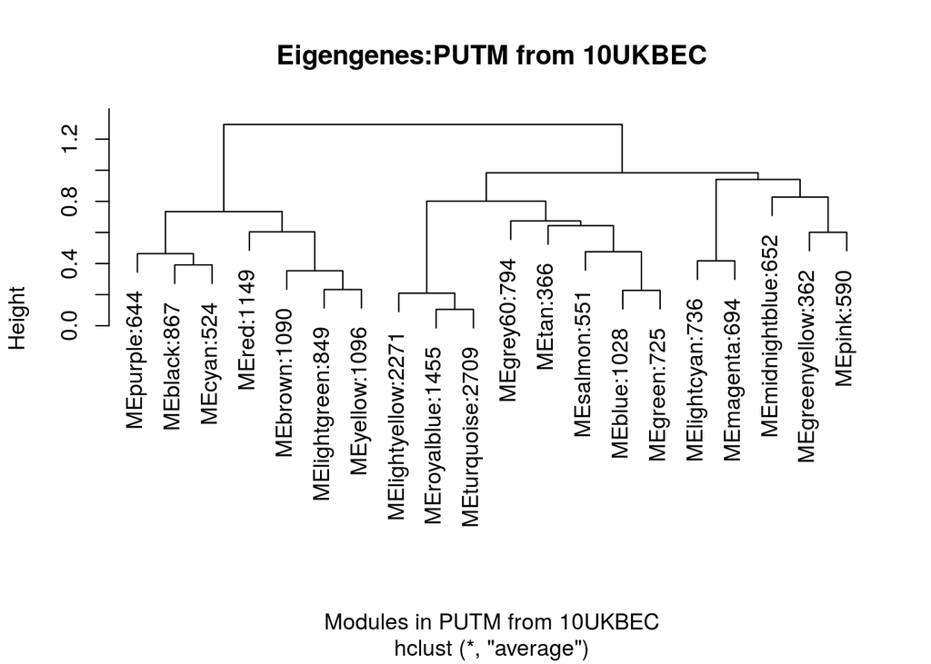

```r
plotEGClustering(which.one = "10UKBEC", tissue = "PUTM")
```

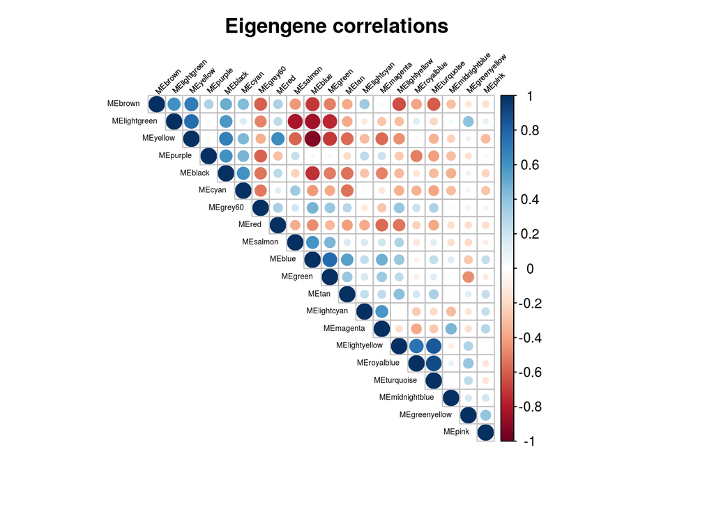

```r
# Display correlations between modules
corrplot(cor(Eigengenes), tl.srt = 45,
         tl.col = "black",
         type = "upper",
         tl.cex = 0.45,
         order = "hclust",
         title = paste0("Eigengene correlations"),
         mar = c(3, 2, 2.5, 4))
```

## 4.2. Gene set enrichment analysis

### NSL genes

First, the **NSL genes** were searched in the coexpression network.

```r
# Search for gene list in dataset
NSL_report2_UK <- reportOnGenes(tissue = "PUTM",
                                genes = NSL_UK_genes,
                                which.one = "10UKBEC")
# Select report
NSL_rep2_UK <- NSL_report2_UK$report
# Count the number of genes in the output
NSL_rep2_UK_length <- nrow(NSL_rep2_UK)
```

The remaining gene was not present in the source file under any aliases and searching in [Braineac](http://www.braineac.org/) itself suggests it is **not present** in this dataset.

```r
# Convert report into dataframe
NSL_rep2_UK <- data.frame(matrix(unlist(NSL_rep2_UK),
                                 nrow = NSL_rep2_UK_length,
                                 byrow = FALSE),
                          stringsAsFactors=FALSE)
names(NSL_rep2_UK)[2] <- "ENSG"
names(NSL_rep2_UK)[3] <- "MM"
names(NSL_rep2_UK)[4] <- "Module"
names(NSL_rep2_UK)[5] <- "Size"
names(NSL_rep2_UK)[6] <- "GO_report"
names(NSL_rep2_UK)[7] <- "PD_genes"
names(NSL_rep2_UK)[8] <- "Preservation"
names(NSL_rep2_UK)[9] <- "Cell_type"
names(NSL_rep2_UK)[10] <- "Fisher"
# Convert gene name column back to more common gene names
UK_genes <- unlist(lapply(NSL_rep2_UK$ENSG, fromEnsembl2GeneName))
UK_genes[UK_genes=="KIAA1267"] <- "KANSL1"
UK_genes[UK_genes=="MYST1"] <- "KAT8"
UK_genes[UK_genes=="C12orf41"] <- "KANSL2"
UK_genes[UK_genes=="KIAA1310"] <- "KANSL3"
# Convert ENSG column back to all ENSGs
UK_ENSGs <- unlist(NSL_rep2_UK$ENSG)
UK_ENSGs[UK_ENSGs=="KIAA1267"] <- "ENSG00000120071"
UK_ENSGs[UK_ENSGs=="MYST1"] <- "ENSG00000103510"
UK_ENSGs[UK_ENSGs=="C12orf41"] <- "ENSG00000139620"
UK_ENSGs[UK_ENSGs=="KIAA1310"] <- "ENSG00000114982"
# Remove first two columns
NSL_rep2_UK <- NSL_rep2_UK[, c(-1, -2)]
NSL_rep2_UK <- data.frame(UK_genes, UK_ENSGs, NSL_rep2_UK)
names(NSL_rep2_UK)[1] <- "Gene"
names(NSL_rep2_UK)[2] <- "ENSG"
# FDR correct
NSL_rep2_UK$FDR <- p.adjust(NSL_rep2_UK$Fisher, method = "fdr")
```

```r
# Print report
NSL_rep2_UK[,c(1,4,3,5,10,11,9)]
```

| Gene | Module | MM | Size | Fisher | FDR | Cell_type |
| --- | --- | --- | --- | --- | --- | --- |
| HCFC1 | purple | 0.8146 | 644 | 0.001867 | 0.004978667 | void |
| KANSL1 | purple | 0.6379 | 644 | 0.001867 | 0.004978667 | void |
| MCRS1 | purple | 0.5865 | 644 | 0.001867 | 0.004978667 | void |
| KANSL2 | lightyellow | 0.443 | 2271 | 0.6358 | 0.635800000 | void |
| KANSL3 | blue | 0.5487 | 1028 | 0.3569 | 0.427771429 | Cortex_Endothelial_Neuroexpresso (p-value 3.852e-22). Endothelial (p-value 4.54e-13). DARMANIS_ENDOTHELIAL (p-value 4.821e-06). Mural (p-value 0.02642). |
| KAT8 | lightcyan | 0.4699 | 736 | 0.2692 | 0.427771429 | void |
| OGT | midnightblue | 0.6278 | 652 | 0.2421 | 0.427771429 | void |
| PHF20 | brown | 0.7249 | 1090 | 0.3743 | 0.427771429 | void |

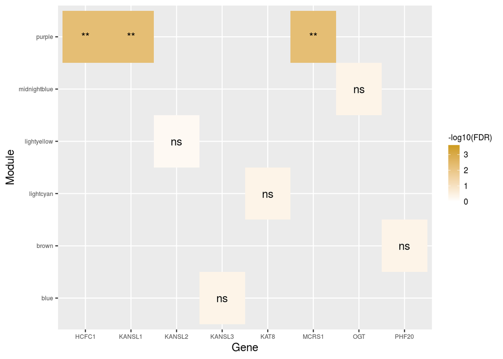

```r
# Store NSL enriched modules
NSL_UK_modules <- unique(NSL_rep2_UK$Module)
# Select columns needed for figure
NSL_fig_UK <- data.frame(NSL_rep2_UK$Module, NSL_rep2_UK$Gene, NSL_rep2_UK$FDR)
names(NSL_fig_UK)[names(NSL_fig_UK)=="NSL_rep2_UK.FDR"] <- "FDR"
names(NSL_fig_UK)[names(NSL_fig_UK)=="NSL_rep2_UK.Module"] <- "Module"
names(NSL_fig_UK)[names(NSL_fig_UK)=="NSL_rep2_UK.Gene"] <- "Gene"
# Prep for figure
NSL_fig_UK$FDR <- as.numeric(NSL_fig_UK$FDR)
NSL_fig_UK$Module <- as.character(NSL_fig_UK$Module)
NSL_fig_UK <- dplyr::arrange(NSL_fig_UK, Module)
NSL_fig_UK$`-log10(FDR)` <- -log10(NSL_fig_UK$FDR)
# Produce plot
ggplot(NSL_fig_UK, aes(Gene, Module)) +
  geom_tile(aes(fill = `-log10(FDR)`)) +
  geom_text(aes(label = signif.num(FDR))) +
  scale_fill_gradient(low = "white", high = "goldenrod3", limits = c(0,3.6)) +
  labs(y = "Module") +
  theme(
    axis.text = element_text(size = 6),
    legend.title = element_text(size = 8),
    legend.text = element_text(size = 8),
    legend.key.size = unit(4, "mm"))
```

The NSL genes appear in modules **purple, lightyellow, blue, lightcyan, midnightblue, brown** but were only significantly enriched in the **purple** module.

### PD mendelian genes

Then the PD mendelian list was searched and the results filtered for the NSL enriched modules.

```r
# Search genes of interest in specified tissue/network
PD_mendelian_report_UK <- reportOnGenes(tissue = "PUTM",
                                        genes = PD_mendelian_genes,
                                        which.one = "10UKBEC")
# Select report
PD_mendelian_rep_UK <- PD_mendelian_report_UK$report
# Count number of genes in output
PD_mendelian_rep_UK_length <- nrow(PD_mendelian_rep_UK)
```

The number of genes is **43** and the number of genes in the search output was **40**, suggesting there were **3** genes missing from the search.

```r
# Show missing genes
dplyr::setdiff(PD_mendelian_genes, PD_mendelian_rep_UK$gene)
```

```
## [1] "MAPT"   "PRKN"   "TUBB4A"
```

```r
# Check if any synonyms of the genes are present in networks
check_synonyms("PUTM",
               "10UKBEC",
               PD_mendelian_genes,
               PD_mendelian_rep_UK$gene)
```

| hgnc_symbol | external_synonym | ensembl_gene_id |
| --- | --- | --- |
| PRKN | PARK2 | ENSG00000185345 |
| TUBB4A | TUBB4 | ENSG00000104833 |

**2** genes appeared in the network under alias names, so these were replaced in the search list.

```r
# Replace this in the list of genes
PD_mendelian_UK_genes <- as.character(PD_mendelian_genes)
PD_mendelian_UK_genes[PD_mendelian_UK_genes=="PRKN"] <- "PARK2"
PD_mendelian_UK_genes[PD_mendelian_UK_genes=="TUBB4A"] <- "TUBB4"
```

The search was then repeated with these changes.

```r
# Again search genes of interest in specified tissue/network
PD_mendelian_report2_UK <- reportOnGenes(tissue = "PUTM",
                                         genes = PD_mendelian_UK_genes,
                                         which.one = "10UKBEC")
# Select report
PD_mendelian_rep2_UK <- PD_mendelian_report2_UK$report
# Count number of genes in output
PD_mendelian_rep2_UK_length <- nrow(PD_mendelian_rep2_UK)
```

```r
dplyr::setdiff(PD_mendelian_UK_genes, PD_mendelian_rep2_UK$gene)
```

```
## [1] "MAPT"
```

The number of genes in the search output was **42**, showing there were **1** fewer genes than the original input list.

```r
# Convert report into dataframe
PD_mendelian_rep2_UK <- data.frame(matrix(unlist(PD_mendelian_rep2_UK),
                                          nrow = PD_mendelian_rep2_UK_length,
                                          byrow = FALSE),
                                   stringsAsFactors=FALSE)
names(PD_mendelian_rep2_UK)[1] <- "Gene"
names(PD_mendelian_rep2_UK)[2] <- "ENSG"
names(PD_mendelian_rep2_UK)[3] <- "MM"
names(PD_mendelian_rep2_UK)[4] <- "Module"
names(PD_mendelian_rep2_UK)[5] <- "Size"
names(PD_mendelian_rep2_UK)[6] <- "GO_report"
names(PD_mendelian_rep2_UK)[7] <- "PD_genes"
names(PD_mendelian_rep2_UK)[8] <- "Preservation"
names(PD_mendelian_rep2_UK)[9] <- "Cell_type"
names(PD_mendelian_rep2_UK)[10] <- "Fisher"
```

```r
# Filter for NSL modules
PD_mendelian_NSL_mod_UK <- PD_mendelian_rep2_UK %>%
  filter(Module %in% NSL_UK_modules)
# Print report without GO term and PD genes column
PD_mendelian_NSL_mod_UK[, c(1,4,3,5,10,9)]
```

| Gene | Module | MM | Size | Fisher | Cell_type |
| --- | --- | --- | --- | --- | --- |
| ATN1 | purple | 0.7244 | 644 | 0.1668 | void |
| ATXN2 | purple | 0.5209 | 644 | 0.1668 | void |
| GRN | purple | 0.5663 | 644 | 0.1668 | void |
| ATXN3 | lightcyan | 0.5669 | 736 | 0.4837 | void |
| PARK7 | lightcyan | 0.2792 | 736 | 0.4837 | void |
| C9orf72 | brown | 0.5592 | 1090 | 0.2153 | void |
| PANK2 | brown | 0.6134 | 1090 | 0.2153 | void |
| RAB39B | brown | 0.6373 | 1090 | 0.2153 | void |
| VPS35 | brown | 0.7409 | 1090 | 0.2153 | void |
| TBP | midnightblue | 0.2929 | 652 | 0.7669 | void |

### PD sporadic genes

The PD sporadic list was also searched and the results filtered for the NSL enriched modules.

```r
# Search genes of interest in specified tissue/network
PD_GWAS_report_UK <- reportOnGenes(tissue = "PUTM",
                                   genes = PD_GWAS_genes,
                                   which.one = "10UKBEC")
# Select report
PD_GWAS_rep_UK <- PD_GWAS_report_UK$report
# Count the number of genes in the output
PD_GWAS_rep_UK_length <- nrow(PD_GWAS_rep_UK)
```

The number of PD GWAS genes is **150** and the number of genes in the search output was **122**, suggesting there were **28** genes missing from the search.

```r
# Show missing genes
dplyr::setdiff(PD_GWAS_genes, PD_GWAS_rep_UK$gene)
```

```
##  [1] "CCAR2"       "CSTA"        "EIF3C"       "FDFT1"       "HCG23"
##  [6] "HIST1H4J"    "HLA-DQA1"    "HLA-DQB1"    "HLA-DRB5"    "HLA-DRB6"
## [11] "KLHL7-DT"    "LINC00174"   "MALSU1"      "MAPT"        "MED13"
## [16] "PGF"         "PPIP5K2"     "PROX2"       "RAB29"       "RETREG3"
## [21] "SGF29"       "SLC26A1"     "TMEM163"     "TMEM248"     "VKORC1"
## [26] "ZKSCAN8"     "ZNF192P1"    "ZSCAN16-AS1"
```

```r
# Check if any synonyms of the genes are present in networks
check_synonyms("PUTM",
               "10UKBEC",
               PD_GWAS_genes,
               PD_GWAS_rep_UK$gene)
```

| hgnc_symbol | external_synonym | ensembl_gene_id |
| --- | --- | --- |
| CCAR2 | DBC1 | ENSG00000158941 |
| CCAR2 | KIAA1967 | ENSG00000158941 |
| LINC00174 | NCRNA00174 | ENSG00000179406 |
| MALSU1 | C7orf30 | ENSG00000156928 |
| PGF | PIGF | ENSG00000119630 |
| PPIP5K2 | HISPPD1 | ENSG00000145725 |
| RAB29 | RAB7L1 | ENSG00000117280 |
| RETREG3 | FAM134C | ENSG00000141699 |
| SGF29 | CCDC101 | ENSG00000176476 |
| TMEM248 | C7orf42 | ENSG00000106609 |

[output cut: 1 more lines]

**11** genes appeared in the network under alias names, so these were replaced in the search list.

```r
# Replace this in the list of genes
PD_GWAS_UK_genes <- as.character(PD_GWAS_genes)
PD_GWAS_UK_genes[PD_GWAS_UK_genes=="CCAR2"] <- "KIAA1967"
PD_GWAS_UK_genes[PD_GWAS_UK_genes=="LINC00174"] <- "NCRNA00174"
PD_GWAS_UK_genes[PD_GWAS_UK_genes=="MALSU1"] <- "C7orf30"
PD_GWAS_UK_genes[PD_GWAS_UK_genes=="PGF"] <- "PIGF"
PD_GWAS_UK_genes[PD_GWAS_UK_genes=="PPIP5K2"] <- "HISPPD1"
PD_GWAS_UK_genes[PD_GWAS_UK_genes=="RAB29"] <- "RAB7L1"
PD_GWAS_UK_genes[PD_GWAS_UK_genes=="RETREG3"] <- "FAM134C"
PD_GWAS_UK_genes[PD_GWAS_UK_genes=="SGF29"] <- "CCDC101"
PD_GWAS_UK_genes[PD_GWAS_UK_genes=="TMEM248"] <- "C7orf42"
PD_GWAS_UK_genes[PD_GWAS_UK_genes=="ZKSCAN8"] <- "ZNF192"
PD_GWAS_UK_genes[PD_GWAS_UK_genes=="ZNF192P1"] <- "ZNF389"
```

The search is was then repeated with these changes.

```r
# Again search genes of interest in specified tissue/network
PD_GWAS_report2_UK <- reportOnGenes(tissue = "PUTM",
                                    genes = PD_GWAS_UK_genes,
                                    which.one = "10UKBEC")
# Select report
PD_GWAS_rep2_UK <- PD_GWAS_report2_UK$report
# Count number of genes in output
PD_GWAS_rep2_UK_length <- nrow(PD_GWAS_rep2_UK)
```

```r
dplyr::setdiff(PD_GWAS_UK_genes, PD_GWAS_rep2_UK$gene)
```

```
##  [1] "CSTA"        "EIF3C"       "FDFT1"       "HCG23"       "HIST1H4J"
##  [6] "HLA-DQA1"    "HLA-DQB1"    "HLA-DRB5"    "HLA-DRB6"    "KLHL7-DT"
## [11] "MAPT"        "MED13"       "PROX2"       "SLC26A1"     "TMEM163"
## [16] "VKORC1"      "ZSCAN16-AS1"
```

```r
# Convert report into dataframe
PD_GWAS_rep2_UK <- data.frame(matrix(unlist(PD_GWAS_rep2_UK),
                                     nrow = PD_GWAS_rep2_UK_length,
                                     byrow = FALSE),
                              stringsAsFactors=FALSE)
names(PD_GWAS_rep2_UK)[1] <- "Gene"
names(PD_GWAS_rep2_UK)[2] <- "ENSG"
names(PD_GWAS_rep2_UK)[3] <- "MM"
names(PD_GWAS_rep2_UK)[4] <- "Module"
names(PD_GWAS_rep2_UK)[5] <- "Size"
names(PD_GWAS_rep2_UK)[6] <- "GO_report"
names(PD_GWAS_rep2_UK)[7] <- "PD_genes"
names(PD_GWAS_rep2_UK)[8] <- "Preservation"
names(PD_GWAS_rep2_UK)[9] <- "Cell_type"
names(PD_GWAS_rep2_UK)[10] <- "Fisher"
```

```r
# Filter for NSL modules
PD_GWAS_NSL_mod_UK <- PD_GWAS_rep2_UK %>%
  filter(Module %in% NSL_UK_modules)
# Print report without GO term and PD genes column
PD_GWAS_NSL_mod_UK[, c(1,4,3,5,10,9)]
```

| Gene | Module | MM | Size | Fisher | Cell_type |
| --- | --- | --- | --- | --- | --- |
| AMPD3 | blue | 0.8133 | 1028 | 0.2929 | Cortex_Endothelial_Neuroexpresso (p-value 3.852e-22). Endothelial (p-value 4.54e-13). DARMANIS_ENDOTHELIAL (p-value 4.821e-06). Mural (p-value 0.02642). |
| ELOVL7 | blue | 0.5673 | 1028 | 0.2929 | Cortex_Endothelial_Neuroexpresso (p-value 3.852e-22). Endothelial (p-value 4.54e-13). DARMANIS_ENDOTHELIAL (p-value 4.821e-06). Mural (p-value 0.02642). |
| HIP1R | blue | 0.7539 | 1028 | 0.2929 | Cortex_Endothelial_Neuroexpresso (p-value 3.852e-22). Endothelial (p-value 4.54e-13). DARMANIS_ENDOTHELIAL (p-value 4.821e-06). Mural (p-value 0.02642). |
| ITPKB | blue | 0.7272 | 1028 | 0.2929 | Cortex_Endothelial_Neuroexpresso (p-value 3.852e-22). Endothelial (p-value 4.54e-13). DARMANIS_ENDOTHELIAL (p-value 4.821e-06). Mural (p-value 0.02642). |
| LAMB2 | blue | 0.6132 | 1028 | 0.2929 | Cortex_Endothelial_Neuroexpresso (p-value 3.852e-22). Endothelial (p-value 4.54e-13). DARMANIS_ENDOTHELIAL (p-value 4.821e-06). Mural (p-value 0.02642). |
| MAP4K4 | blue | 0.9215 | 1028 | 0.2929 | Cortex_Endothelial_Neuroexpresso (p-value 3.852e-22). Endothelial (p-value 4.54e-13). DARMANIS_ENDOTHELIAL (p-value 4.821e-06). Mural (p-value 0.02642). |
| PARP9 | blue | 0.6963 | 1028 | 0.2929 | Cortex_Endothelial_Neuroexpresso (p-value 3.852e-22). Endothelial (p-value 4.54e-13). DARMANIS_ENDOTHELIAL (p-value 4.821e-06). Mural (p-value 0.02642). |
| STK39 | blue | 0.3887 | 1028 | 0.2929 | Cortex_Endothelial_Neuroexpresso (p-value 3.852e-22). Endothelial (p-value 4.54e-13). DARMANIS_ENDOTHELIAL (p-value 4.821e-06). Mural (p-value 0.02642). |
| STX4 | blue | 0.4552 | 1028 | 0.2929 | Cortex_Endothelial_Neuroexpresso (p-value 3.852e-22). Endothelial (p-value 4.54e-13). DARMANIS_ENDOTHELIAL (p-value 4.821e-06). Mural (p-value 0.02642). |
| SATB1 | brown | 0.4358 | 1090 | 0.8849 | void |

[output cut: 36 more lines]

### Gene ontology terms

To examine the functional characteristics of these modules, the GO term enrichments annotated to these modules were extracted and simplified according to parent terms.

```r
# Obtain gprofiler2 network annotations from the UKBEC package
e2 = read.csv(file.path(here::here("data",
                                   "CoExp_source",
                                   "netPUTM.12.signed.it.20.rds_cor_pca.rds_gprofiler.csv")),
              stringsAsFactors = FALSE)
# Extract all GO term enrichments from source file for modules of interest
NSL_UK_GO = e2[e2$query.number %in% NSL_UK_modules & e2$domain %in% c("BP", "CC", "MF"),]
NSL_UK_GO_2 <- dplyr::select(NSL_UK_GO, query.number, term.id, term.name, domain, p.value)
# Rename columns
names(NSL_UK_GO_2)[names(NSL_UK_GO_2)=="query.number"] <- "gene_list"
names(NSL_UK_GO_2)[names(NSL_UK_GO_2)=="term.id"] <- "go_id"
names(NSL_UK_GO_2)[names(NSL_UK_GO_2)=="domain"] <- "go_type"
names(NSL_UK_GO_2)[names(NSL_UK_GO_2)=="term.name"] <- "go_term"
# FDR correct p values
NSL_UK_GO_2$p.value <- as.numeric(NSL_UK_GO_2$p.value)
NSL_UK_GO_2$FDR <- p.adjust(NSL_UK_GO_2$p.value, method="fdr")
```

```r
# GO reduce
NSL_UK_GO_red <- go_reduce(pathway_df = NSL_UK_GO_2, threshold = 0.7, scores = NULL)
```

The GO term enrichments attached to these modules were extracted and simplified according to parent terms, then plotted.

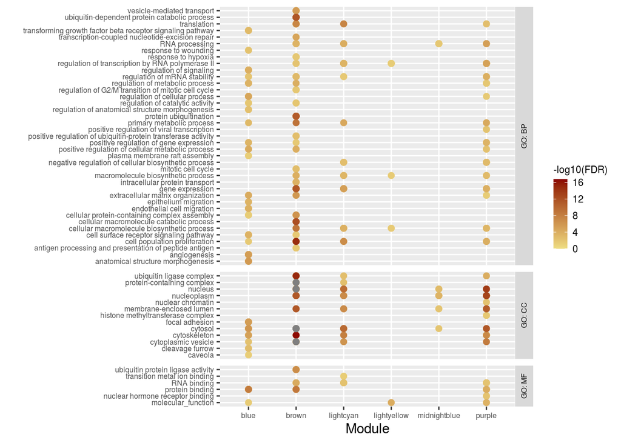

```r
# Format
NSL_UK_GO_red$go_type[NSL_UK_GO_red$go_type=="BP"] <- "GO: BP"
NSL_UK_GO_red$go_type[NSL_UK_GO_red$go_type=="MF"] <- "GO: MF"
NSL_UK_GO_red$go_type[NSL_UK_GO_red$go_type=="CC"] <- "GO: CC"
NSL_UK_GO_red <- NSL_UK_GO_red %>%
  tidyr::drop_na(parent_term) %>%
  dplyr::arrange(desc(FDR))
# Plot
ggplot2::ggplot(NSL_UK_GO_red, aes(x = gene_list, y = parent_term)) +
  geom_point(size = 2, aes(colour = -log10(`FDR`))) +
  scale_color_continuous(low = "lightgoldenrod", high = "red4", limits = c(0,16.8)) +
  facet_grid(go_type ~., scales = "free", space = "free") +
  labs(x = "Module", y = "") +
  theme(
    strip.text.y = element_text(angle = 90, size = 6),
    axis.text = element_text(size = 6),
    legend.title = element_text(size = 8),
    legend.text = element_text(size = 8),
    legend.key.size = unit(4, "mm")
    )
```

## 4.2. Summary

The **frequency** of **genes** within each gene **list** apppearing in each of the **6 NSL enriched modules** was calculated.

```r
# Collate module results into one table
UK1 <- PD_mendelian_NSL_mod_UK['Module']
UK1['Gene_list'] <- "PD_mendelian"
UK2 <- PD_GWAS_NSL_mod_UK['Module']
UK2['Gene_list'] <- "PD_GWAS"
UK_mods_list <- do.call(rbind, list(UK1, UK2))
# Display as frequency of each module within each list
UK_mod_freq <- with(UK_mods_list, table(Module, Gene_list))
UK_mod_freq <- as.data.frame.matrix(UK_mod_freq)
```

```r
knitr::kable(UK_mod_freq)
```

|  | PD_GWAS | PD_mendelian |
| --- | --- | --- |
| blue | 9 | 0 |
| brown | 5 | 4 |
| lightcyan | 5 | 2 |
| lightyellow | 11 | 0 |
| midnightblue | 6 | 1 |
| purple | 10 | 3 |

The **significance** of the **enrichments** of each **gene list** within each of the **6 NSL enriched modules** was also calculated. P-values were **FDR-corrected** before summarising.

```r
# FDR correct p values
PD_mendelian_rep2_UK$FDR <- p.adjust(PD_mendelian_rep2_UK$Fisher, method = "fdr")
PD_GWAS_rep2_UK$FDR <- p.adjust(PD_GWAS_rep2_UK$Fisher, method = "fdr")
```

```r
# Collate module results into one table
UKs1 <- data.frame(PD_mendelian_rep2_UK$Module, PD_mendelian_rep2_UK$FDR)
names(UKs1)[names(UKs1)=="PD_mendelian_rep2_UK.FDR"] <- "FDR"
names(UKs1)[names(UKs1)=="PD_mendelian_rep2_UK.Module"] <- "Module"
UKs1$Gene_list <- "PD_mendelian"
UKs2 <- data.frame(PD_GWAS_rep2_UK$Module, PD_GWAS_rep2_UK$FDR)
names(UKs2)[names(UKs2)=="PD_GWAS_rep2_UK.FDR"] <- "FDR"
names(UKs2)[names(UKs2)=="PD_GWAS_rep2_UK.Module"] <- "Module"
UKs2$Gene_list <- "PD_GWAS"
UK_pvals_list <- dplyr::bind_rows(UKs1, UKs2)
# Display as true/false table
UK_TF <- UK_pvals_list %>%
  dplyr::distinct() %>%
  tidyr::spread(Gene_list, FDR)
UK_TF <- dplyr::filter(UK_TF, Module %in% NSL_UK_modules)
UK_TF <- tibble::column_to_rownames(UK_TF, var = "Module")
```

```r
knitr::kable(UK_TF)
```

|  | PD_GWAS | PD_mendelian |
| --- | --- | --- |
| blue | 0.6030000 | NA |
| brown | 0.9575000 | 0.3783111 |
| lightcyan | 0.9575000 | 0.5975118 |
| lightyellow | 0.9575000 | NA |
| midnightblue | 0.6030000 | 0.8258923 |
| purple | 0.0751393 | 0.3783111 |

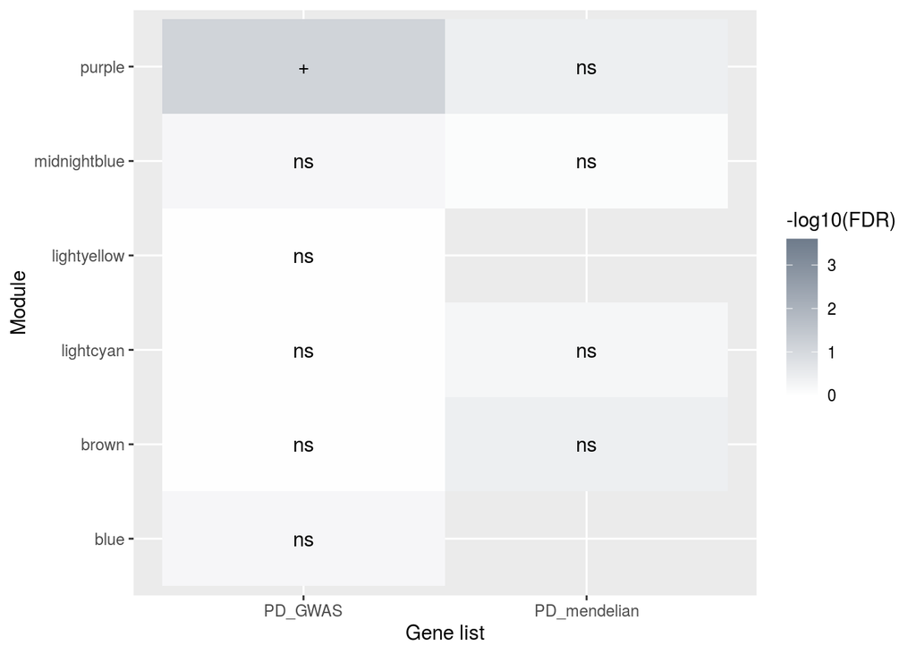

```r
# Filter out small mitopahgy list and modules without NSL genes
melt_summ_UK <- UK_pvals_list %>%
  dplyr::filter(Module %in% NSL_UK_modules) %>%
  dplyr::distinct()
# Prep for figure
melt_summ_UK$FDR <- as.numeric(melt_summ_UK$FDR)
melt_summ_UK$Module <- as.character(melt_summ_UK$Module)
melt_summ_UK$Gene_list <- as.character(melt_summ_UK$Gene_list)
melt_summ_UK <- dplyr::arrange(melt_summ_UK, Module)
melt_summ_UK$`-log10(FDR)` <- -log10(melt_summ_UK$FDR)
# Plot
ggplot(melt_summ_UK, aes(Gene_list, Module)) +
  geom_tile(aes(fill = `-log10(FDR)`)) +
  geom_text(aes(label = signif.num(FDR))) +
  scale_fill_gradient(low = "white", high = "lightsteelblue4", limits = c(0,3.6)) +
  labs(y = "Module", x = "Gene list")
```